# Machine Learning: Modelos no Supervisados

## Práctica Final

### 22 de enero del 2022

### Cristina Rubiales e Isabel Marsá - 4ºB

#### Una compañía e-Commerce que vende productos alimenticios via, lanza regularmente ofertas y campañas a sus clientes. Con el objetivo de optimizar el ratio de éxito cuando crea una nueva campaña o cuando llega un nuevo cliente (y no tiene todavía suficiente información para modelar la afinidad entre una campaña y sus clientes) quiere realizar una segmentación de sus clientes y campañas para abordar este problema con mayor facilidad.

Nos encontramos ante un caso muy real, ya que como ocurre la mayoría de las veces, los datos no vienen con etiquetas predefinidas, es decir, no tenemos información que relacione el éxito entre un grupo de clientes y una campaña. Por tanto, vamos a tener que desarrollar modelos de aprendizaje no supervisados que clasificarán correctamente estos datos, hayando por sí mismos puntos en común en las características, que se utilizaremos para predecir las clases sobre nuevos datos.

Trabajaremos con la base de datos de clientes de la empresa donde encontramos características de cada cliente, la de campañas con las características de las mismas y otra llamada campaigns_to_customers_launched que detalla qué campañas se ha lanzado a cada cliente y si estas campañas fueron aprobadas o no. El objetivo de este análisis es realizar grupos de clientes que compartan características similares y asignarles la campaña que vayan a aceptar con una probabilidad mayor.

Las bases de datos con las que trabajaremos son muy complejas, por lo que primero realizaremos un análisis general de las mismas. Deberemos hacer una reducción de dimensiones, que consiste en el proceso de reducir el número de variables aleatorias del conjunto de datos mediante la obtención de un conjunto de variables principales. También realizaremos un análisis cluster para encontrar patrones en los datos y poder asignar un grupo de campaña al grupo de clientes que vaya a aceptar dicha campaña con mayor probabilidad.

# Campaigns to Customers Launched

#### 1.- Para hacer una posterior evaluación de los métodos desarrollados, divide el dataset campaigns_to_customers_launched.csv en training, validation y test.

```python
import numpy as np
import pandas as pd
import matplotlib.pyplot as plt
import seaborn as sns
from csv import reader

from sklearn.cluster import DBSCAN
from sklearn import metrics
from sklearn.preprocessing import StandardScaler
from sklearn.datasets import fetch_openml

import matplotlib.pyplot as plt
from sklearn.manifold import TSNE
import seaborn as sns
import time

from sklearn.cluster import KMeans
from sklearn.metrics import silhouette_samples
import matplotlib.cm as cm
from sklearn.metrics import homogeneity_score, completeness_score, v_measure_score, \
    adjusted_mutual_info_score, adjusted_rand_score
from sklearn.metrics.cluster import contingency_matrix
from sklearn.model_selection import train_test_split
from sklearn.decomposition import PCA
from matplotlib.patches import Ellipse

import warnings
warnings.filterwarnings('ignore')
```

Lo primero de todo importaremos los datos con la librería de pandas y realizaremos un análisis general de los mismos. En caso de haber valores missing, los trataremos y eliminaremos variables que no aporten nada a nuestro análisis para quedarnos con una base de datos más reducida que facilite el trabajo con estos datos.

```python
data = pd.read_csv('campaigns_to_customers_launched.csv')
```

```python
data = data.drop(columns="Unnamed: 0")
data.head()
```

|  | customer | campaign | result |
| --- | --- | --- | --- |
| 0 | 1650 | 34 | 1 |
| 1 | 1168 | 85 | 0 |
| 2 | 2142 | 36 | 0 |
| 3 | 1536 | 12 | 0 |
| 4 | 1072 | 74 | 0 |

Como podemos comprobar, esta base de datos no contiene datos missing:

```python
def missing_summary(dataframe):
    num_elementos = data.count()
    num_missing = data.isna().sum()
    missing_summary = pd.DataFrame(index=num_elementos.index,
                               data={'total':num_elementos,
                                     'missing':num_missing,
                                     'missing_rate (%)': round(num_missing/num_elementos * 100, 2)})
    return missing_summary
```

```python
missing_summary(data)
```

|  | total | missing | missing_rate (%) |
| --- | --- | --- | --- |
| customer | 13440 | 0 | 0.0 |
| campaign | 13440 | 0 | 0.0 |
| result | 13440 | 0 | 0.0 |

Para ver cuantas campañas hay de cada grupo y cuantos clientes hay en cada campaña, agruparemos los datos con la función group.by y obtenemos la siguiente tabla:

```python
campana = data.groupby('campaign')
campana.agg('count').customer
```

```
campaign
0     146
1     128
2     146
3     132
4     134
     ...
95    131
96    131
97    143
98    132
99    121
Name: customer, Length: 100, dtype: int64
```

```python
random_state=100 #instertamos la semilla
```

```python
data_train, data_validationtest = train_test_split(data, test_size = 0.4, random_state = random_state)
data_validation, data_test = train_test_split(data_validationtest, test_size = 0.5, random_state = random_state)
```

# Customers

#### 2.- Realiza las acciones adecuadas sobre customers.csv:

#### 2.1 Realiza una transformación adecuada del dataset customers.csv para su posterior procesamiento. (Tips: recuerda eliminar ids, transformar variables discretas, y cambiar fechas a días hasta el día actual, por ejemplo.)

```python
customerdf = pd.read_csv('customers.csv')
```

```python
customer = customerdf.drop(columns="customer_id")
customer
```

|  | Year_Birth | Education | Marital_Status | Income | Kidhome | Teenhome | Dt_Customer | Recency | MntWines | MntFruits | ... | MntGoldProds | NumDealsPurchases | NumWebPurchases | NumCatalogPurchases | NumStorePurchases | NumWebVisitsMonth | Complain | Z_CostContact | Z_Revenue | Response |
| --- | --- | --- | --- | --- | --- | --- | --- | --- | --- | --- | --- | --- | --- | --- | --- | --- | --- | --- | --- | --- | --- |
| 0 | 1957 | Graduation | Single | 58138.0 | 0 | 0 | 2012-09-04 | 58 | 635 | 88 | ... | 88 | 3 | 8 | 10 | 4 | 7 | 0 | 3 | 11 | 1 |
| 1 | 1954 | Graduation | Single | 46344.0 | 1 | 1 | 2014-03-08 | 38 | 11 | 1 | ... | 6 | 2 | 1 | 1 | 2 | 5 | 0 | 3 | 11 | 0 |
| 2 | 1965 | Graduation | Together | 71613.0 | 0 | 0 | 2013-08-21 | 26 | 426 | 49 | ... | 42 | 1 | 8 | 2 | 10 | 4 | 0 | 3 | 11 | 0 |
| 3 | 1984 | Graduation | Together | 26646.0 | 1 | 0 | 2014-02-10 | 26 | 11 | 4 | ... | 5 | 2 | 2 | 0 | 4 | 6 | 0 | 3 | 11 | 0 |
| 4 | 1981 | PhD | Married | 58293.0 | 1 | 0 | 2014-01-19 | 94 | 173 | 43 | ... | 15 | 5 | 5 | 3 | 6 | 5 | 0 | 3 | 11 | 0 |
| ... | ... | ... | ... | ... | ... | ... | ... | ... | ... | ... | ... | ... | ... | ... | ... | ... | ... | ... | ... | ... | ... |
| 2235 | 1967 | Graduation | Married | 61223.0 | 0 | 1 | 2013-06-13 | 46 | 709 | 43 | ... | 247 | 2 | 9 | 3 | 4 | 5 | 0 | 3 | 11 | 0 |
| 2236 | 1946 | PhD | Together | 64014.0 | 2 | 1 | 2014-06-10 | 56 | 406 | 0 | ... | 8 | 7 | 8 | 2 | 5 | 7 | 0 | 3 | 11 | 0 |
| 2237 | 1981 | Graduation | Divorced | 56981.0 | 0 | 0 | 2014-01-25 | 91 | 908 | 48 | ... | 24 | 1 | 2 | 3 | 13 | 6 | 0 | 3 | 11 | 0 |
| 2238 | 1956 | Master | Together | 69245.0 | 0 | 1 | 2014-01-24 | 8 | 428 | 30 | ... | 61 | 2 | 6 | 5 | 10 | 3 | 0 | 3 | 11 | 0 |
| 2239 | 1954 | PhD | Married | 52869.0 | 1 | 1 | 2012-10-15 | 40 | 84 | 3 | ... | 21 | 3 | 3 | 1 | 4 | 7 | 0 | 3 | 11 | 1 |

2240 rows × 23 columns

Primero realizamos un análisis de la base de datos de Customers, donde se definen las características de los clientes de la compañía e-commerce. Observamos que cada cliente está identificado con un ID y encontramos variables como su estado marital, nivel de educación o si el cliente ha tenido quejas en los dos últimos años o no.

A continuación utilizaremos una función que nos permitirá identificar si las variables contienen datos numéricos o categóricos:

```python
df_types = customer.dtypes
print(df_types)
```

```
Year_Birth               int64
Education               object
Marital_Status          object
Income                 float64
Kidhome                  int64
Teenhome                 int64
Dt_Customer             object
Recency                  int64
MntWines                 int64
MntFruits                int64
MntMeatProducts          int64
MntFishProducts          int64
MntSweetProducts         int64
MntGoldProds             int64
NumDealsPurchases        int64
NumWebPurchases          int64
NumCatalogPurchases      int64
NumStorePurchases        int64
NumWebVisitsMonth        int64
Complain                 int64
Z_CostContact            int64
Z_Revenue                int64
Response                 int64
dtype: object
```

Tanto Marital_Status como Dt_Customer y Education son variables categóricas, por lo que las transformaremos en numéricas más adelante para poder trabajar con ellas. Primero nos centraremos en Dt_Customer.

Dt_Customer es la variable que indica la fecha en la que el cliente tuvo la primera compra. Trabajaremos sobre esta variable para calcular los días transcurridos desde esa fecha. Para ello crearemos una variable llamada'Días_transcurridos' donde meteremos la diferencia del día de hoy y la fecha de la primera compra de dicho cliente:

```python
customer["Dt_Customer"] = pd.to_datetime(customer["Dt_Customer"],
                                    format="%Y-%m-%d")
```

```python
today = pd.datetime.now()
customer["Días_transcurridos"] = (today - customer["Dt_Customer"]).dt.days
customer
```

|  | Year_Birth | Education | Marital_Status | Income | Kidhome | Teenhome | Dt_Customer | Recency | MntWines | MntFruits | ... | NumDealsPurchases | NumWebPurchases | NumCatalogPurchases | NumStorePurchases | NumWebVisitsMonth | Complain | Z_CostContact | Z_Revenue | Response | Días_transcurridos |
| --- | --- | --- | --- | --- | --- | --- | --- | --- | --- | --- | --- | --- | --- | --- | --- | --- | --- | --- | --- | --- | --- |
| 0 | 1957 | Graduation | Single | 58138.0 | 0 | 0 | 2012-09-04 | 58 | 635 | 88 | ... | 3 | 8 | 10 | 4 | 7 | 0 | 3 | 11 | 1 | 3426 |
| 1 | 1954 | Graduation | Single | 46344.0 | 1 | 1 | 2014-03-08 | 38 | 11 | 1 | ... | 2 | 1 | 1 | 2 | 5 | 0 | 3 | 11 | 0 | 2876 |
| 2 | 1965 | Graduation | Together | 71613.0 | 0 | 0 | 2013-08-21 | 26 | 426 | 49 | ... | 1 | 8 | 2 | 10 | 4 | 0 | 3 | 11 | 0 | 3075 |
| 3 | 1984 | Graduation | Together | 26646.0 | 1 | 0 | 2014-02-10 | 26 | 11 | 4 | ... | 2 | 2 | 0 | 4 | 6 | 0 | 3 | 11 | 0 | 2902 |
| 4 | 1981 | PhD | Married | 58293.0 | 1 | 0 | 2014-01-19 | 94 | 173 | 43 | ... | 5 | 5 | 3 | 6 | 5 | 0 | 3 | 11 | 0 | 2924 |
| ... | ... | ... | ... | ... | ... | ... | ... | ... | ... | ... | ... | ... | ... | ... | ... | ... | ... | ... | ... | ... | ... |
| 2235 | 1967 | Graduation | Married | 61223.0 | 0 | 1 | 2013-06-13 | 46 | 709 | 43 | ... | 2 | 9 | 3 | 4 | 5 | 0 | 3 | 11 | 0 | 3144 |
| 2236 | 1946 | PhD | Together | 64014.0 | 2 | 1 | 2014-06-10 | 56 | 406 | 0 | ... | 7 | 8 | 2 | 5 | 7 | 0 | 3 | 11 | 0 | 2782 |
| 2237 | 1981 | Graduation | Divorced | 56981.0 | 0 | 0 | 2014-01-25 | 91 | 908 | 48 | ... | 1 | 2 | 3 | 13 | 6 | 0 | 3 | 11 | 0 | 2918 |
| 2238 | 1956 | Master | Together | 69245.0 | 0 | 1 | 2014-01-24 | 8 | 428 | 30 | ... | 2 | 6 | 5 | 10 | 3 | 0 | 3 | 11 | 0 | 2919 |
| 2239 | 1954 | PhD | Married | 52869.0 | 1 | 1 | 2012-10-15 | 40 | 84 | 3 | ... | 3 | 3 | 1 | 4 | 7 | 0 | 3 | 11 | 1 | 3385 |

2240 rows × 24 columns

Tras haber analizado de forma general los datos, eliminamos algunas variables que son redundantes con otra variable y que no son necesarias para nuestro estudio, para trabajar con un dataset de menor tamaño que facilite el análisis: la variable Dt_Customer nos indica la fecha en la que le cliente realizó la primera compra con la empresa y ya no nos sirve de nada porque lo que necesitamos son los días transcurridos, que ya hemos calculado para cada cliente con la variable Días_transcurridos. Hemos formado una nuevas variable a partir de una que ya no necesitamos: Dt_Customer. Por otro lado, Z_CostContact y Z_Revenue son dos variables que, tras haber analizado el dataset, hemos descubierto que no aportan nada de información para el estudio. Por último, la variable Response indica si el cliente ha respondido o no a la encuesta, lo cual aporta poca información, por tanto, también nos desharemos de esta variable.

```python
customer = customer.drop(columns="Dt_Customer")
customer = customer.drop(columns="Z_CostContact")
customer = customer.drop(columns="Z_Revenue")
customer = customer.drop(columns="Response")
```

Tratamos los valores missing y detectamos que la variable 'Income' contiene algún valor de este tipo, por ello sustituiremos estos valores missing por la media de los ingresos del resto de clientes.

```python
def missing_summary(dataframe):
    num_elementos = customer.count()
    num_missing = customer.isna().sum()
    missing_summary = pd.DataFrame(index=num_elementos.index,
                               data={'total':num_elementos,
                                     'missing':num_missing,
                                     'missing_rate (%)': round(num_missing/num_elementos * 100, 2)})
    return missing_summary
```

```python
mean_income=customer['Income'].mean()
print('La media de ingresos de los clientes es',mean_income, 'euros')
```

```
La media de ingresos de los clientes es 52247.25135379061 euros
```

```python
customer['Income'] = customer['Income'].fillna(mean_income)
```

Ahora transformaremos las variables categóricas en variables numéricas. Tanto Marital_Status como Education son variables no ordinales ya que los valores de las mismas no siguen una secuencia, es decir, no hay valores mejores que otros. Encontramos valores como estado de soltería, casado, educación básica, master, graduado, PhD, etc. Estos valores no tienen una secuencia, por tanto, utilizaremos la técnica de One-Hot-Encoding que nos permitirá quedarnos con una variable nueva por cada valor distinto. Para ello utilizaremos la función de pandas get_dummies como se muestra en el código a continuación:

```python
custo= pd.get_dummies(customer, columns=["Marital_Status", "Education"])
custo
```

|  | Year_Birth | Income | Kidhome | Teenhome | Recency | MntWines | MntFruits | MntMeatProducts | MntFishProducts | MntSweetProducts | ... | Marital_Status_Married | Marital_Status_Single | Marital_Status_Together | Marital_Status_Widow | Marital_Status_YOLO | Education_2n Cycle | Education_Basic | Education_Graduation | Education_Master | Education_PhD |
| --- | --- | --- | --- | --- | --- | --- | --- | --- | --- | --- | --- | --- | --- | --- | --- | --- | --- | --- | --- | --- | --- |
| 0 | 1957 | 58138.0 | 0 | 0 | 58 | 635 | 88 | 546 | 172 | 88 | ... | 0 | 1 | 0 | 0 | 0 | 0 | 0 | 1 | 0 | 0 |
| 1 | 1954 | 46344.0 | 1 | 1 | 38 | 11 | 1 | 6 | 2 | 1 | ... | 0 | 1 | 0 | 0 | 0 | 0 | 0 | 1 | 0 | 0 |
| 2 | 1965 | 71613.0 | 0 | 0 | 26 | 426 | 49 | 127 | 111 | 21 | ... | 0 | 0 | 1 | 0 | 0 | 0 | 0 | 1 | 0 | 0 |
| 3 | 1984 | 26646.0 | 1 | 0 | 26 | 11 | 4 | 20 | 10 | 3 | ... | 0 | 0 | 1 | 0 | 0 | 0 | 0 | 1 | 0 | 0 |
| 4 | 1981 | 58293.0 | 1 | 0 | 94 | 173 | 43 | 118 | 46 | 27 | ... | 1 | 0 | 0 | 0 | 0 | 0 | 0 | 0 | 0 | 1 |
| ... | ... | ... | ... | ... | ... | ... | ... | ... | ... | ... | ... | ... | ... | ... | ... | ... | ... | ... | ... | ... | ... |
| 2235 | 1967 | 61223.0 | 0 | 1 | 46 | 709 | 43 | 182 | 42 | 118 | ... | 1 | 0 | 0 | 0 | 0 | 0 | 0 | 1 | 0 | 0 |
| 2236 | 1946 | 64014.0 | 2 | 1 | 56 | 406 | 0 | 30 | 0 | 0 | ... | 0 | 0 | 1 | 0 | 0 | 0 | 0 | 0 | 0 | 1 |
| 2237 | 1981 | 56981.0 | 0 | 0 | 91 | 908 | 48 | 217 | 32 | 12 | ... | 0 | 0 | 0 | 0 | 0 | 0 | 0 | 1 | 0 | 0 |
| 2238 | 1956 | 69245.0 | 0 | 1 | 8 | 428 | 30 | 214 | 80 | 30 | ... | 0 | 0 | 1 | 0 | 0 | 0 | 0 | 0 | 1 | 0 |
| 2239 | 1954 | 52869.0 | 1 | 1 | 40 | 84 | 3 | 61 | 2 | 1 | ... | 1 | 0 | 0 | 0 | 0 | 0 | 0 | 0 | 0 | 1 |

2240 rows × 31 columns

```python
df_types = custo.dtypes
print(df_types)
```

```
Year_Birth                   int64
Income                     float64
Kidhome                      int64
Teenhome                     int64
Recency                      int64
MntWines                     int64
MntFruits                    int64
MntMeatProducts              int64
MntFishProducts              int64
MntSweetProducts             int64
MntGoldProds                 int64
NumDealsPurchases            int64
NumWebPurchases              int64
NumCatalogPurchases          int64
NumStorePurchases            int64
NumWebVisitsMonth            int64
Complain                     int64
Días_transcurridos           int64
Marital_Status_Absurd        uint8
Marital_Status_Alone         uint8
Marital_Status_Divorced      uint8
Marital_Status_Married       uint8
Marital_Status_Single        uint8
Marital_Status_Together      uint8
Marital_Status_Widow         uint8
Marital_Status_YOLO          uint8
Education_2n Cycle           uint8
Education_Basic              uint8
Education_Graduation         uint8
Education_Master             uint8
Education_PhD                uint8
dtype: object
```

Comprobamos los distintos valores de cada variable categórica para hacernos una idea de los estados civiles más y menos comunes y el tipo de eduación recibida:

```python
status = customer.groupby('Marital_Status')
status.agg('count').Income
```

```
Marital_Status
Absurd        2
Alone         3
Divorced    232
Married     864
Single      480
Together    580
Widow        77
YOLO          2
Name: Income, dtype: int64
```

Podemos comprobar aqui que el estado civil más común en nuestra base de datos es estado casado ('married') con un total de 864 clientes casados y los menos comunes son 'Absurd' y 'YOLO'.

```python
educ = customer.groupby('Education')
educ.agg('count').Income
```

```
Education
2n Cycle       203
Basic           54
Graduation    1127
Master         370
PhD            486
Name: Income, dtype: int64
```

El nivel de educación recibida más común es el grado ('Graduation'), es decir, la mayoría de los clientes tienen un grado, seguido por el doctorado ('PhD') y el Master. El menos común como podemos ver es la educación básica.

Esto nos ayuda a conocer mejor a los clientes, ya que podemos comprobar que en general, tienen un nivel de educación bastante elevado. Además hemos calculado anteriormente la media de los ingresos de los clientes, siendo este valor 52,247.25€, lo cual es un valor bastante elevado. Por tanto, se puede decir que trabajamos con un nicho de mercado con poder adquisitivo y buen nivel de educación.

#### 2.2.- ¿Debes normalizar los datos?. si es así, realiza la normalización.

Es conviniente que normalicemos las variables de esta base de datos para poder trabajar con ellas ya que el cálculo de los componentes principales depende de las unidades de medida empleadas en las variables. Esto se debe a que cada variable está medida en una escala diferente. El problema de las escalas diferentes es que luego el análisis le va a dar mayor peso a las variables que estén en escalas mayores. Para evitar esto, lo que haremos es normalizar las variables manualmente, de manera que tengan media cero y desviación estándar uno, ya que, de lo contrario, las variables con mayor varianza dominarían al resto, aunque en el caso en que las variables estén medidas en las mismas unidades, podemos optar por no estandarizarlas. La estandarización se lleva a cabo restando a cada observación la media y dividiendo entre la desviación estándar de la variable a la que pertenece.

El objetivo final de realizar la normalización es reducir todas las características a una escala común sin distorsionar las diferencias en el rango de los valores. El proceso de PCA consiste en identificae las direcciones donde la sea mayor la varianza. La varianza de una variable se mide en su escala elevada al cuadrado. Si antes de calcular los componentes no se normalizan las las variables, las variables cuya escala sea mayor predominarán. Por ello es recomendable estandarizar siempre los datos.

Normalmente, hay que realizar la normalización sobre el conjunto de entrenamiento, pero en este caso no vamos a crear un conjunto de entrenamiento con la base de datos de clientes ya que no es necesario.

```python
custnorm = (custo-custo.mean()) / custo.std()
custnorm.head(5)
```

|  | Year_Birth | Income | Kidhome | Teenhome | Recency | MntWines | MntFruits | MntMeatProducts | MntFishProducts | MntSweetProducts | ... | Marital_Status_Married | Marital_Status_Single | Marital_Status_Together | Marital_Status_Widow | Marital_Status_YOLO | Education_2n Cycle | Education_Basic | Education_Graduation | Education_Master | Education_PhD |
| --- | --- | --- | --- | --- | --- | --- | --- | --- | --- | --- | --- | --- | --- | --- | --- | --- | --- | --- | --- | --- | --- |
| 0 | -0.985125 | 0.235274 | -0.825033 | -0.929687 | 0.306971 | 0.983562 | 1.551231 | 1.679327 | 2.461597 | 1.476170 | ... | -0.792229 | 1.914427 | -0.590967 | -0.188634 | -0.029887 | -0.315613 | -0.157136 | 0.993548 | -0.444716 | -0.526267 |
| 1 | -1.235457 | -0.235774 | 1.032328 | 0.906732 | -0.383579 | -0.870285 | -0.636159 | -0.713066 | -0.650304 | -0.631362 | ... | -0.792229 | 1.914427 | -0.590967 | -0.188634 | -0.029887 | -0.315613 | -0.157136 | 0.993548 | -0.444716 | -0.526267 |
| 2 | -0.317572 | 0.773461 | -0.825033 | -0.929687 | -0.797908 | 0.362642 | 0.570677 | -0.176993 | 1.344974 | -0.146872 | ... | -0.792229 | -0.522116 | 1.691387 | -0.188634 | -0.029887 | -0.315613 | -0.157136 | 0.993548 | -0.444716 | -0.526267 |
| 3 | 1.267866 | -1.022504 | 1.032328 | -0.929687 | -0.797908 | -0.870285 | -0.560732 | -0.651041 | -0.503862 | -0.582913 | ... | -0.792229 | -0.522116 | 1.691387 | -0.188634 | -0.029887 | -0.315613 | -0.157136 | 0.993548 | -0.444716 | -0.526267 |
| 4 | 1.017534 | 0.241465 | 1.032328 | -0.929687 | 1.549959 | -0.388998 | 0.419822 | -0.216866 | 0.155129 | -0.001525 | ... | 1.261698 | -0.522116 | -0.590967 | -0.188634 | -0.029887 | -0.315613 | -0.157136 | -1.006045 | -0.444716 | 1.899327 |

5 rows × 31 columns

```python
def missing_summary(dataframe):
    num_elementos = custnorm.count()
    num_missing = custnorm.isna().sum()
    missing_summary = pd.DataFrame(index=num_elementos.index,
                               data={'total':num_elementos,
                                     'missing':num_missing,
                                     'missing_rate (%)': round(num_missing/num_elementos * 100, 2)})
    return missing_summary
```

```python
missing_summary(custnorm)
```

|  | total | missing | missing_rate (%) |
| --- | --- | --- | --- |
| Year_Birth | 2240 | 0 | 0.0 |
| Income | 2240 | 0 | 0.0 |
| Kidhome | 2240 | 0 | 0.0 |
| Teenhome | 2240 | 0 | 0.0 |
| Recency | 2240 | 0 | 0.0 |
| MntWines | 2240 | 0 | 0.0 |
| MntFruits | 2240 | 0 | 0.0 |
| MntMeatProducts | 2240 | 0 | 0.0 |
| MntFishProducts | 2240 | 0 | 0.0 |
| MntSweetProducts | 2240 | 0 | 0.0 |
| MntGoldProds | 2240 | 0 | 0.0 |
| NumDealsPurchases | 2240 | 0 | 0.0 |
| NumWebPurchases | 2240 | 0 | 0.0 |
| NumCatalogPurchases | 2240 | 0 | 0.0 |
| NumStorePurchases | 2240 | 0 | 0.0 |
| NumWebVisitsMonth | 2240 | 0 | 0.0 |
| Complain | 2240 | 0 | 0.0 |
| Días_transcurridos | 2240 | 0 | 0.0 |
| Marital_Status_Absurd | 2240 | 0 | 0.0 |
| Marital_Status_Alone | 2240 | 0 | 0.0 |
| Marital_Status_Divorced | 2240 | 0 | 0.0 |
| Marital_Status_Married | 2240 | 0 | 0.0 |
| Marital_Status_Single | 2240 | 0 | 0.0 |
| Marital_Status_Together | 2240 | 0 | 0.0 |
| Marital_Status_Widow | 2240 | 0 | 0.0 |
| Marital_Status_YOLO | 2240 | 0 | 0.0 |
| Education_2n Cycle | 2240 | 0 | 0.0 |
| Education_Basic | 2240 | 0 | 0.0 |
| Education_Graduation | 2240 | 0 | 0.0 |
| Education_Master | 2240 | 0 | 0.0 |
| Education_PhD | 2240 | 0 | 0.0 |

#### 2.3.- Puede ser interesante realizar un análisis descriptivo con algún mapa de correlación y un t-sne, pca o similar para ver como se distribuyen los datos.

Es probable que las variables de los datos con tendencias similares contengan información muy parecida, y solo una de ellas nos hará falta para la clasificación. Ahora calcularemos el coeficiente de correlación entre columnas numéricas haciendo un "heatmap". Es importante destacar que la correlación depende del rango de columnas por lo que es fundamental normalizarla antes de aplicar la técnica.

Nos quedaremos con las variables que pueden mantener algo de correlación entre ellas y nos deshacemos de las columnas creadas por el One Hot encoding para realizar un heatmap de las correlaciones y poderlo visualizar fácilmente:

```python
custnorm_corr=custnorm.drop(['Marital_Status_Absurd', 'Marital_Status_Alone',
       'Marital_Status_Divorced', 'Marital_Status_Married',
       'Marital_Status_Single', 'Marital_Status_Together',
       'Marital_Status_Widow', 'Marital_Status_YOLO', 'Education_2n Cycle',
       'Education_Basic', 'Education_Graduation', 'Education_Master',
       'Education_PhD'],axis=1)
```

```python
corr = custnorm_corr.corr()
```

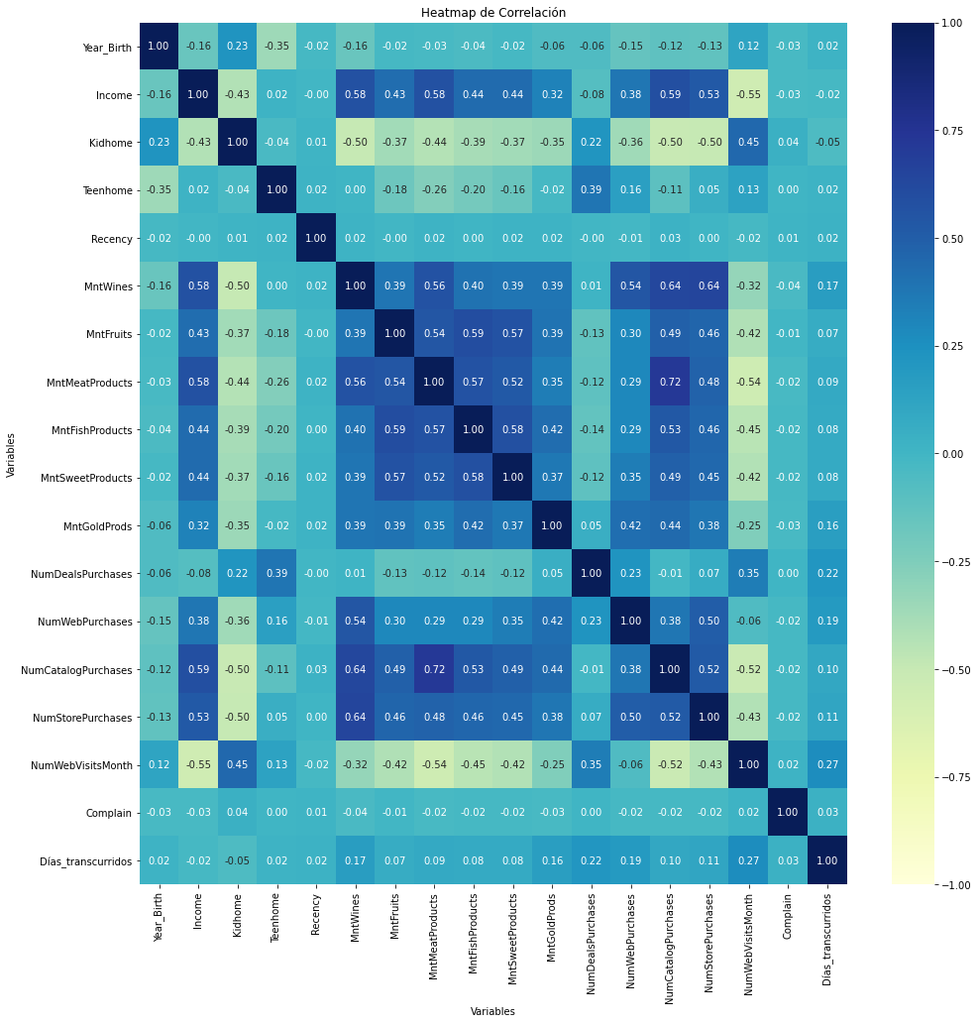

```python
plt.figure(figsize=(16,16))
ax=sns.heatmap(corr, cmap='YlGnBu',
               annot=True,
              vmin=-1,
               vmax=1,
               center=0,fmt='.2f')# con fmt especificamos 2 dígitos de precisión y f se utiliza para representar un nºdecimal
ax.set(title='Heatmap de Correlación',
      ylabel='Variables',
      xlabel='Variables')
plt.show()
```

En este gráfico de correlación comprobamos que las variables que más correlación guardan entre ellas son: NumCatalogPurchases y MntMeatProducts con un valor de 0.72; NumCatalogPurchases y MntWines; NumStorePurchases y MntWines con 0.64; Income y NumCatalogPurchases; MntFishProducts y MntFruits con 0.59, NumWebVisitsMonth y Kidhome con 0.45. Tras observar este gráfico podemos sacar la conclusión de que por ejemplo, el vino y la carne se compra normalmente a través del catálogo de la tienda ya que estos valores están altamente correlacionado: cuando sube el número de compra de carne y vino, sube el valor de compras a través del catálogo. Además cuantos más niños pequeños tiene el cliente en casa (Kidhome), más visitas realiza en la página web. Los compradores de vino lo suelen realizar sobre todo a través del catálogo y de la tienda.

Ni la variable de número de días desde la última compra (Recency) ni la variable Complain tienen correlación alguna con ninguna variables. Podríamos destacar que estas dos variables no explican mucho en nuestro análisis. Días transcurridos tampoco tiene demasiada correlación con el resto de variables.

```python
print('Original dataset shape: ',customer.shape)
```

```
Original dataset shape:  (2240, 20)
```

```python
print('Transformed dataset shape: ',custnorm.shape)
```

```
Transformed dataset shape:  (2240, 31)
```

## Principal Component Analysis

```python
# Realizamos el primer modelo PCA con 31 componentes

pca = PCA(31, random_state=random_state, whiten=False)
datatrain = pca.fit_transform(custnorm)

xs= [i[0] for i in datatrain]
ys= [i[1] for i in datatrain]
```

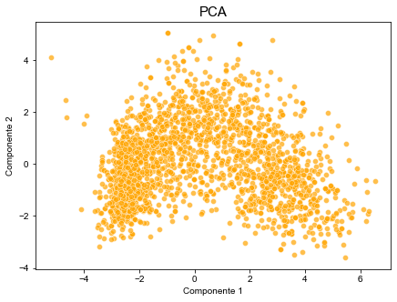

```python
plt.subplots(figsize=(7,5))
sns.scatterplot(x=xs, y=ys,color='orange',alpha=0.7)
plt.xlabel("Componente 1", fontsize = 10)
plt.ylabel("Componente 2", fontsize = 10)
plt.title('PCA', fontsize = 15)
sns.set(rc={"figure.figsize":(8, 4)})
plt.figure(num=None, figsize=(10, 10), dpi=80, facecolor='w', edgecolor='k')
```

El vector que define la primera componente principal (Componente 1) sigue la dirección en la que las observaciones varían más. La proyección de cada observación sobre esa dirección equivale al valor de la primera componente para dicha observación. La segunda componente (Componente 2) sigue la segunda dirección en la que los datos muestran mayor varianza y que no está correlacionada con la primera componente. La condición de no correlación entre componentes principales equivale a decir que sus direcciones son ortogonales.

La función de sklearn .fit_transform() ajusta el modelo creado de PCA, con los datos de entrenamiento, custnorm en nuestro caso y aplica la reducción de la dimensionalidad. Es decir, entrena el modelo PCA con los datos de entrada. La función fit_transform() se utiliza en los datos de entrenamiento para que podamos escalar los datos de entrenamiento y también aprender los parámetros de escalado de esos datos. Aquí, el modelo construido por nosotros aprenderá la media y la varianza de las características del conjunto de entrenamiento. Estos parámetros aprendidos se utilizan para escalar nuestros datos de prueba. La diferencia entre fit() y fit_transform() es que el método fit consiste en calcular la media y la varianza de cada una de las características presentes en nuestros datos y el método de fit_transform transforma todas las características utilizando la media y la varianza respectivas.

El método de PCA permite simplificar la información aportada por muchas variables en pocos componentes. Esto lo convierte en un método muy útil de aplicar previa utilización de otras técnicas estadísticas que utilizaremos más adelante como por ejemplo clustering.

Cuando se trabaja con las varianzas, el PCA es muy sensible a los valores atípicos, por lo que es importante estudiar si los hay. A continuación, detectaremos los outliers mediante el PCA:

```python
recoveryx=pca.inverse_transform(datatrain)

originalx=custnorm.to_numpy()

restx=(originalx-recoveryx)**2

score=np.sum(restx,1)

score_mean=np.mean(score)

score_std=np.std(score)

mark_outlier=np.where(score>score_mean+5*score_std,True, False)
```

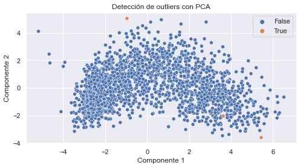

```python
sns.scatterplot(datatrain[:,0],datatrain[:,1],hue=mark_outlier)
plt.title('Detección de outliers con PCA')
plt.xlabel('Componente 1')
plt.ylabel('Componente 2')
```

```python
sumoutliers=np.sum(mark_outlier)
print("Total de outliers en la base de datos:", sumoutliers)
```

```
Total de outliers en la base de datos: 5
```

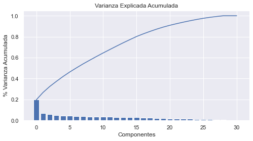

```python
varianza = pca.explained_variance_ratio_
var_acum= np.cumsum(varianza)
plt.bar(range(len(varianza)), varianza)
plt.plot(range(len(varianza)), var_acum)
plt.title('Varianza Explicada Acumulada')
plt.xlabel('Componentes')
plt.ylabel('% Varianza Acumulada')

plt.show()
```

Con este gráfico de la varianza explicada acumulada, nos hacemos una idea principal de cuánto explican x componentes, ahora vamos a estudiar esto con más detalle para considerar con cuántos componentes nos podemos quedar para realizar un buen análisis. Con la función de sklearn explained_variance*ratio* obtendremos la varianza explicada por cada componente, como se muestra a continuación. Como resultado de la transformación que hemos realizado, el primer componente principal tiene la mayor varianza posible.

```python
pve=pca.explained_variance_ratio_
print('Porcentaje de varianza explicada por cada componente:')
print('')
print(pve)
```

```
Porcentaje de varianza explicada por cada componente:

[1.97029193e-01 6.98734057e-02 5.69785571e-02 4.89089017e-02
 4.67013560e-02 4.28494026e-02 3.95251369e-02 3.81414955e-02
 3.55679225e-02 3.48628306e-02 3.39936000e-02 3.27015386e-02
 3.25354330e-02 3.17846530e-02 3.02797351e-02 2.97835359e-02
 2.52368904e-02 2.32451685e-02 2.19191898e-02 1.97870313e-02
 1.73782608e-02 1.52507598e-02 1.44080397e-02 1.34496265e-02
 1.24061171e-02 1.10846415e-02 9.54720292e-03 7.90989939e-03
 6.86047465e-03 3.88571570e-32 9.48440427e-33]
```

```python
main_vars1ej=sorted([(abs(el), i) for i, el in enumerate(pca.components_[0])], reverse=True)
main_vars1ej[:3]
```

```
[(0.32982326053678246, 13), (0.32145521369127045, 7), (0.30442878299442067, 5)]
```

```python
[custnorm.columns[i] for n, i in main_vars1ej[:3]]
```

```
['NumCatalogPurchases', 'MntMeatProducts', 'MntWines']
```

Estas son las variables que forman el primer componente. Observamos que las variables que más varianza explican son el número de compras a través del catálogo, la cantidad gastada en carne y vino en los dos últimos años. Estas variables están bastante correlacionadas entre ellas como hemos podido comprobar anteriormente en el heatmap.

```python
main_vars1ejb=sorted([(abs(el), i) for i, el in enumerate(pca.components_[1])], reverse=True)
main_vars1ejb[:3]
```

```
[(0.47330730180236974, 3), (0.4120530796481156, 11), (0.3283877778991308, 0)]
```

```python
[custnorm.columns[i] for n, i in main_vars1ejb[:3]]
```

```
['Teenhome', 'NumDealsPurchases', 'Year_Birth']
```

Las variables del segundo componente son el número de adolescentes'Teenhome', el número de compras hechas con descuento'NumDealsPurchases' y el año de nacimiento del cliente,'Year_Birth'.

```python
two_comp=sum(pca.explained_variance_ratio_[:2])
three_comp=sum(pca.explained_variance_ratio_[:3])
four_comp=sum(pca.explained_variance_ratio_[:4])
```

```python
print("La  varianza explicada con los dos primeros componentes es", two_comp)
print("La  varianza explicada con los tres primeros componentes es", three_comp)
print("La  varianza explicada con los cuatro primeros componentes es", four_comp)
```

```
La  varianza explicada con los dos primeros componentes es 0.2669025991911434
La  varianza explicada con los tres primeros componentes es 0.3238811562804871
La  varianza explicada con los cuatro primeros componentes es 0.3727900579731313
```

El objetivo del PCA es reducir la dimensionalidad, por tanto es conveniente utilizar el mínimo número de componentes que resultan suficientes para explicar los datos. No existe una respuesta o método único. A continuación vamos a proceder a evaluar la proporción de varianza explicada acumulada y seleccionaremos el número de componentes mínimo a partir del cual el incremento deja de ser sustancial. Hemos creido que el número de componentes que expliquen el 99% de la varianza es un número muy significativo:

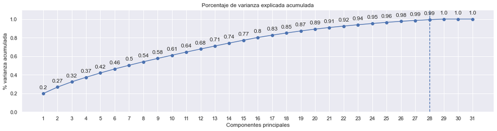

```python
prop_varianza_acum = pca.explained_variance_ratio_.cumsum()
fig, ax = plt.subplots(nrows=1, ncols=1, figsize=(18, 4))
ax.plot(
    np.arange(pca.n_components_) + 1,
    prop_varianza_acum,
    marker = 'o'
)

for x, y in zip(np.arange(pca.n_components_) + 1, prop_varianza_acum):
    label = round(y, 2)
    ax.annotate(
        label,
        (x,y),
        textcoords="offset points",
        xytext=(0,10),
        ha='center'
    )

ax.axvline(x=28, linestyle = '--') #en el 28 componente se explica el 99% de la varianza
ax.set_ylim(0, 1.1)
ax.set_xticks(np.arange(pca.n_components_) + 1)
ax.set_title('Porcentaje de varianza explicada acumulada')
ax.set_xlabel('Componentes principales')
ax.set_ylabel('% varianza acumulada')
```

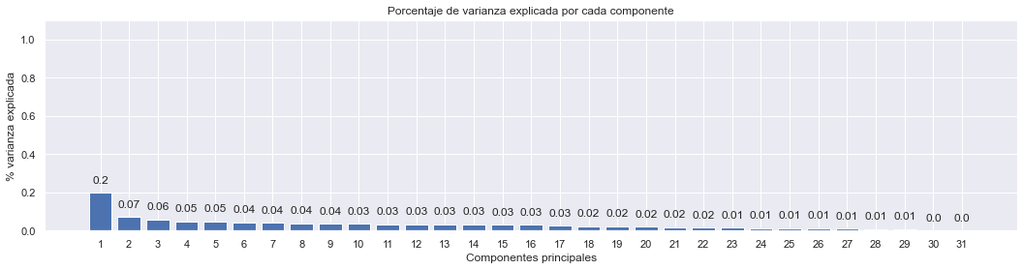

```python
fig, ax = plt.subplots(nrows=1, ncols=1, figsize=(18, 4))
ax.bar(
    x      = np.arange(pca.n_components_) + 1,
    height = pca.explained_variance_ratio_
)

for x, y in zip(np.arange(pca.n_components_) + 1, pca.explained_variance_ratio_):
    label = round(y, 2)
    ax.annotate(
        label,
        (x,y),
        textcoords="offset points",
        xytext=(0,10),
        ha='center'
    )

ax.set_xticks(np.arange(pca.n_components_) + 1)
ax.set_ylim(0, 1.1)
ax.set_title('Porcentaje de varianza explicada por cada componente')
ax.set_xlabel('Componentes principales')
ax.set_ylabel('% varianza explicada')
```

Este gráfico indica el porcentaje de la varianza explicada de cada uno de los componentes. Podemos observar que el componente 1 explica el 20% de la varianza, que es un valor muy elevado, a diferencia del componente 2 que simplemente explica el 7% de la varianza. El componente 3 explica el 6% de la varianza y el componente 4 explica 5% también. Destacar también que los componentes 30 y 31 no explican prácticamente nada de la varianza.

## T-Sne

La técnica de PCA sufre de algunas limitaciones a la hora de reducir la dimensionalidad, por ejemplo, solo considera combinaciones lineales de las variables originales. En algunos casos, el no poder considerar otro tipo de combinaciones conllevará a eliminar mucha información útil. T-Sne (t-distributed stochastic neighbor embedding) es un método no lineal que consigue superar esta limitación y por lo tanto supera al PCA. Intenta encontrar una representación (no-lineal) de los datos usando pocas dimensiones que preserve las distancias entre cada punto y sus vecinos en el espacio multi-dimensional.

A continuación crearemos un T-Sne que detectará patrones en los datos sobre los que estamos trabajando. La idea principal de este algoritmo es tratar de mantener los puntos que aparecen cercanos en altas dimensiones también en las dimensiones reducidas, sin preocuparse por preservar esa distancia en puntos que aparecen distantes en altas dimensiones. T-sne calcula la probabilidad condicional de cada par de observaciones y de minimiza la suma de las diferencias entre las probabilidades de la dimensión superior e inferior. Primero vamos a analizar el efecto del parámetro perplexity, que está relacionado con el número de vecinos utilizado apra construir dicho algoritmo. Utilizaremos los valores 1, 10, 25 y 75 y veremos cual es el más adecuado para nuestro estudio:

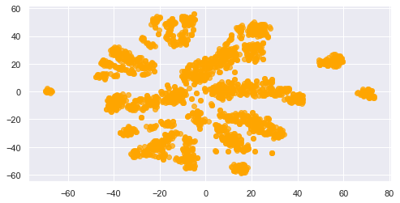

```python
modelo= TSNE(learning_rate=50)
tsne_features=modelo.fit_transform(custnorm)
xss=tsne_features[:,0]
yss=tsne_features[:,1]
plt.scatter(xss,yss,alpha=0.75,color='orange')

plt.show()
```

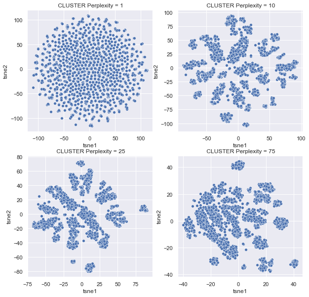

```python
plt.figure(figsize = (10,4))
plt.subplots_adjust(top = 2.0)

for index, p in enumerate([1, 10, 25, 75]):

    tsne = TSNE(n_components = 2, perplexity = p, random_state=random_state)
    tsne_results = tsne.fit_transform(custnorm)

    tsne_results=pd.DataFrame(tsne_results, columns=['tsne1', 'tsne2'])

    plt.subplot(2,2,index+1)
    sns.scatterplot(tsne_results['tsne1'], tsne_results['tsne2'], s=30)
    plt.title(' CLUSTER Perplexity = '+ str(p))

plt.show()
```

Podemos ver que la perplejidad que más nos aporta es 25, por ello utilizaremos este valor de perplejidad para realizar los clusters. También, en el gráfico 3 vemos una clara segmentación por clusters. Con este análisis podemos hacernos una idea inicial de cómo se agrupan los datos. Haciendo un análisis a simple vista podemos distinguir un gran número de agrupaciones, por tanto, a la hora de hacer el análisis cluster con KMeans tendremos que utilizar muchos clusters para realizar un estudio correcto. Esto se puede dar por ejemplo, porque hay distintos segmentos de clientes con carácteristicas muy diferentes que les hacen consumir de formas diferentes. Es por ello muy interesante hacer esta segmentación de clientes, ya que hay consumidores que reaccionan diferentemente entre ellos y a los cuales habría que crear una campaña distinta para cada grupo.

#### 2.4.- Haz un clustering haciendo uso de K-means, de la base de datos de customers. Recuerda optimizar el valor adecuado de componentes.

El clustering es un conjunto de técnicas utilizadas para dividir los datos en grupos. Los clusters se definen de forma imprecisa como grupos de objetos de datos que son más similares a otros objetos de su clúster que a los de otros clusters.

En esta práctica, la agrupación nos ayudará a identificar grupos de clientes que se comportan de manera parecida y de esta manerá facilitará a la compañía de e-commerce para la que estamos trabajando a lanzar la campaña más efectiva para cada tipo de cliente según esta segmentación. Utilizaremos el algoritmo KMeans ya que queremos agrupar datos con patrones parecidos pero no sabemos realmente a qué etiqueta pertenece cada dato. Crearemos una variable de etiquetas, que llamamos labels4, que es un array con el número de cluster al que aparece cada dato.

```python
kmeansclust=KMeans(n_clusters=4)
```

```python
labels4=kmeansclust.fit_predict(custnorm)
print(labels4)
```

```
[3 1 3 ... 3 0 1]
```

```python
centroid=kmeansclust.fit(custnorm)
centroides=centroid.cluster_centers_ #asignamos los centroides
```

Todos los centroides del KMeans se almacenan en el atributo cluster_centers. Un centroide es la ubicación imaginaria o real que representa el centro del clúster. Cada punto de datos se asigna a cada uno de los clústeres mediante la reducción de la suma de cuadrados dentro del clúster. En otras palabras, el algoritmo K-means identifica un número k de centroides y asigna cada punto de datos al clúster más cercano, manteniendo los centroides lo más pequeños posible.

Inspeccionamos el cluster y observamos los distintos centroides del clustering, que en este caso son 4:

```python
cx=centroides[:,0]
cy=centroides[:,1]
```

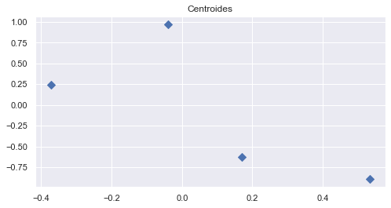

```python
plt.scatter(cx,cy,marker='D',s=50)
plt.title('Centroides')
plt.show()
```

```python
custnorm['Cluster']=labels4
```

```python
custnorm.head(4) # Cada customer es asignado a un cluster en la última columna
```

|  | Year_Birth | Income | Kidhome | Teenhome | Recency | MntWines | MntFruits | MntMeatProducts | MntFishProducts | MntSweetProducts | ... | Marital_Status_Single | Marital_Status_Together | Marital_Status_Widow | Marital_Status_YOLO | Education_2n Cycle | Education_Basic | Education_Graduation | Education_Master | Education_PhD | Cluster |
| --- | --- | --- | --- | --- | --- | --- | --- | --- | --- | --- | --- | --- | --- | --- | --- | --- | --- | --- | --- | --- | --- |
| 0 | -0.985125 | 0.235274 | -0.825033 | -0.929687 | 0.306971 | 0.983562 | 1.551231 | 1.679327 | 2.461597 | 1.476170 | ... | 1.914427 | -0.590967 | -0.188634 | -0.029887 | -0.315613 | -0.157136 | 0.993548 | -0.444716 | -0.526267 | 3 |
| 1 | -1.235457 | -0.235774 | 1.032328 | 0.906732 | -0.383579 | -0.870285 | -0.636159 | -0.713066 | -0.650304 | -0.631362 | ... | 1.914427 | -0.590967 | -0.188634 | -0.029887 | -0.315613 | -0.157136 | 0.993548 | -0.444716 | -0.526267 | 1 |
| 2 | -0.317572 | 0.773461 | -0.825033 | -0.929687 | -0.797908 | 0.362642 | 0.570677 | -0.176993 | 1.344974 | -0.146872 | ... | -0.522116 | 1.691387 | -0.188634 | -0.029887 | -0.315613 | -0.157136 | 0.993548 | -0.444716 | -0.526267 | 3 |
| 3 | 1.267866 | -1.022504 | 1.032328 | -0.929687 | -0.797908 | -0.870285 | -0.560732 | -0.651041 | -0.503862 | -0.582913 | ... | -0.522116 | 1.691387 | -0.188634 | -0.029887 | -0.315613 | -0.157136 | 0.993548 | -0.444716 | -0.526267 | 1 |

4 rows × 32 columns

Hemos creado cuatro clusters donde se añadirá cada cliente según sus características. Ahora plasmaremos un boxplot para ver como se relaciona cada elemento del cluster con el número de compras a través de la página web y otro boxplot para ver como se relaciona cada elemento del cluster con la variable ingresos, Income:

```python
custnorm[['Cluster','NumWebPurchases']].head(10)
```

|  | Cluster | NumWebPurchases |
| --- | --- | --- |
| 0 | 3 | 1.408989 |
| 1 | 1 | -1.110161 |
| 2 | 3 | 1.408989 |
| 3 | 1 | -0.750283 |
| 4 | 1 | 0.329353 |
| 5 | 0 | 0.689232 |
| 6 | 0 | 1.049111 |
| 7 | 1 | -0.030525 |
| 8 | 1 | -0.390404 |
| 9 | 1 | -1.110161 |

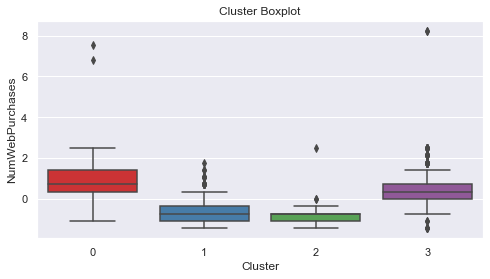

```python
sns.boxplot(x='Cluster',y='NumWebPurchases',data=custnorm,palette="Set1")
plt.title('Cluster Boxplot')
```

```python
clust = custnorm.groupby('Cluster')
group_by_cluster=clust.agg('count').Income
group_by_cluster
```

```
Cluster
0    607
1    999
2     54
3    580
Name: Income, dtype: int64
```

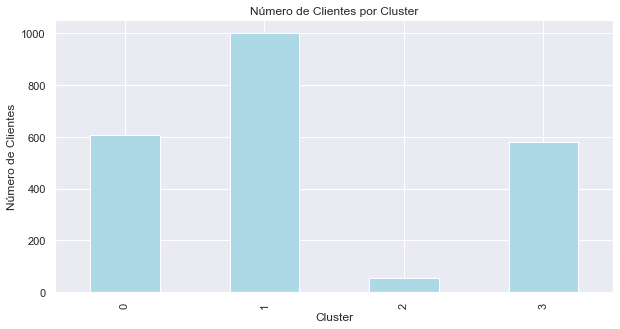

```python
group_by_cluster.plot.bar(color='lightblue',figsize=(10,5))
plt.title('Número de Clientes por Cluster')
plt.ylabel('Número de Clientes')
plt.xlabel('Cluster')
```

## KMeans Clustering

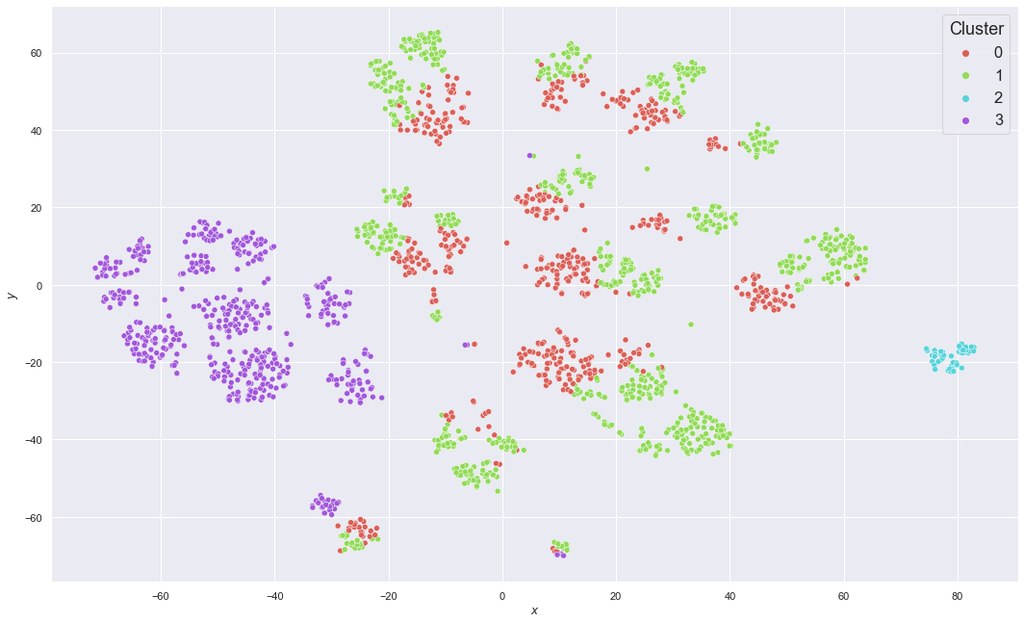

```python
tsne = TSNE(n_components=2, perplexity=25, random_state=random_state)
data_tsne = tsne.fit_transform(custnorm)

df_tsne = pd.DataFrame(data_tsne, columns=['x', 'y'], index=custnorm.index)
dff = pd.concat([custnorm, df_tsne], axis=1)


fig, ax = plt.subplots(figsize=(18, 11))
with sns.plotting_context("notebook", font_scale=1.5):
    sns.scatterplot(x='x',
                    y='y',
                    hue='Cluster',
                    palette=sns.color_palette("hls", 4),
                    data=dff,
                    ax=ax)

ax.set_xlabel(r'$x$')
ax.set_ylabel(r'$y$')

plt.show()
```

De entrada, en este gráfico T-sne podemos observar que los datos claramente se agrupan en múltiples clusters, como hemos analizado anteriormente. El problema que hemos encontrado con el algoritmo T-sne es que no nos puede mostrar la estructura global de los datos, es decir, muestra los distintos clusters pero estos son muy poco intuitivos ya que no están agrupados por colores. Este algoritmo es lento en la fase de entrenamiento, por lo que hemos decidido utilizar el algoritmo de KMeans para realizar una clusterización más intuitiva y visual. El parámetro random_state en el caso de clustering, determina la generación de números aleatorios para la inicialización del centroide.

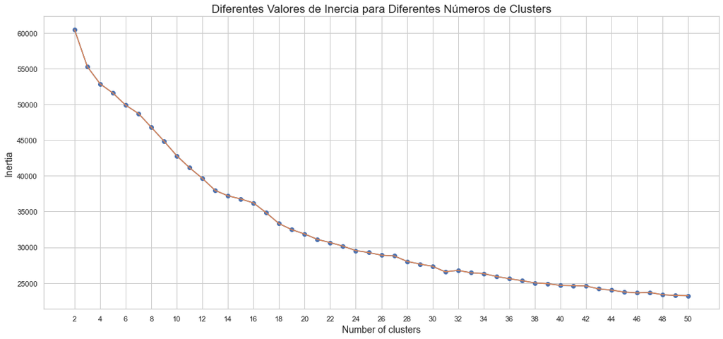

```python
plt.rcParams['figure.figsize'] = [8,8]
sns.set_style("whitegrid")
colors = plt.rcParams['axes.prop_cycle'].by_key()['color']

# Computamos la inercia

inertias = []

for i in range(2, 51):
    km = KMeans(n_clusters=i, max_iter=1000, random_state=random_state)
    km.fit(custnorm)
    inertias.append(km.inertia_)

# Mostramos el plot de inercia vs. el número de clusters

fig, ax = plt.subplots(figsize=(18, 8))

ax.plot(np.arange(2, 51, 1), inertias)
ax.set_xlabel('Number of clusters', fontsize=14)
ax.set_ylabel('Inertia', fontsize=14)
ax.set_xticks(np.arange(2, 51, 2))

plt.plot(range(2,51),inertias)
plt.scatter(range(2,51),inertias)

plt.title("Diferentes Valores de Inercia para Diferentes Números de Clusters", size=17)

plt.show()
```

A continuación realizamos un nuevo Kmeans con el valor óptimo de clusters: 20

```python
kmeansclust6=KMeans(20) #indicamos el nº óptimo de clusters según la regla del codo
labls6=kmeansclust6.fit_predict(custnorm)
```

```python
custnorm['cluster']=labls6
```

```python
centroid6=kmeansclust6.fit(custnorm)
centroides6=centroid6.cluster_centers_ #asignamos los centroides
```

```python
cx6=centroides6[:,0]
cy6=centroides6[:,1]
```

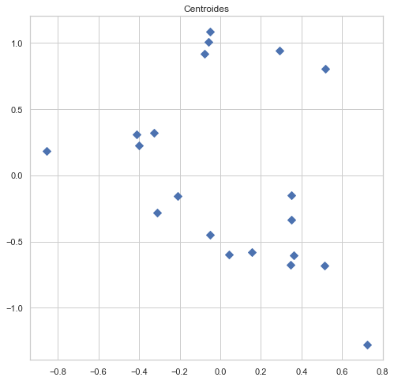

```python
plt.scatter(cx6,cy6,marker='D',s=50)
plt.title('Centroides')
plt.show()
```

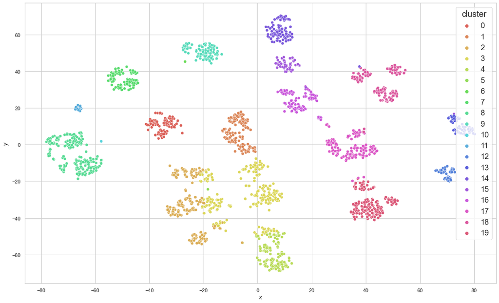

```python
tsne = TSNE(n_components=2, perplexity=25, random_state=random_state)
data_tsne = tsne.fit_transform(custnorm)

df_tsne = pd.DataFrame(data_tsne, columns=['x', 'y'], index=custnorm.index)
dff = pd.concat([custnorm, df_tsne], axis=1)

# Diagrama

fig, ax = plt.subplots(figsize=(18, 11))
with sns.plotting_context("notebook", font_scale=1.5):
    sns.scatterplot(x='x',
                    y='y',
                    hue='cluster',
                    palette=sns.color_palette("hls", 20),
                    data=dff,
                    ax=ax)

ax.set_xlabel(r'$x$')
ax.set_ylabel(r'$y$')

plt.show()
```

Podemos obsevar en este gráfico los veinte clusters de nuestra base de datos de clientes. Esta segmentación esta muy bien definida y las agrupaciones se pueden haber dado por las distintas características de los numerosos clientes que tiene la empresa. Este clustering nos ayuda a entender mejor los datos con los que estamos trabajando. Gracias a este clustering vamos a ahorrar mucho tiempo ya que en vez de tratar a cada cliente individualmente, trataremos cada cluster de forma personalizada ¡no es lo mismo trabajar con 20 tipos de cliente que con más de 2000 clientes!. Para esto es realmente el análisis cluster que estamos realizando. Hemos podido comprobar que el algoritmo KMeans es muy eficiente y rápido y produce resultados muy intuitivos.

## Silhouette Coefficient

Ahora, utilizamos la función de sklearn .metrics.silhouette_score donde pasa el conjunto de datos y las etiquetas para evaluar cómo de bueno es el cluster del análisis que acabamos de realizar y cúal es el número óptimo de clusters.

El Silhouette Coefficient se calcula utilizando la distancia media entre clusters (a) y la distancia media entre clusters más cercanos (b) para cada muestra. El coeficiente de silueta de una muestra es (distancia media entre clusters - distancia media entre clusters más cercanos) entre el valor máximo entre estos dos números.

Esta función devuelve el Coeficiente de Silueta (Silhouette Coefficient) medio sobre todas las muestras. Para obtener los valores de cada muestra, utilizaré silhouette_samples.

El análisis de siluetas puede utilizarse para estudiar la distancia de separación entre los clusters resultantes. El gráfico de siluetas muestra una medida de la proximidad de cada punto de un conglomerado a los puntos de los conglomerados vecinos y, por tanto, proporciona una forma de evaluar visualmente parámetros como el número de clusters.

El mejor valor es 1 y el peor es -1. Los valores cercanos a 0 indican que los clusters se solapan. Los valores negativos generalmente indican que una muestra ha sido asignada al cluster equivocado, ya que un cluster diferente es más similar.

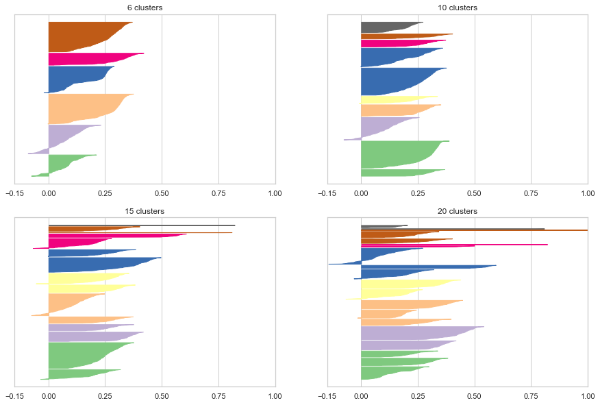

```python
nb_clusters = [6, 10, 15, 20]
mapping = [(0, 0), (0, 1), (1, 0), (1, 1)]

# Coeficiente Silhouette

fig, ax = plt.subplots(2, 2, figsize=(15, 10))
for i, n in enumerate(nb_clusters):
    km = KMeans(n_clusters=n, random_state=random_state)
    Y = km.fit_predict(custnorm)
    Y_pred = km.fit_predict(custnorm)
    df_km = pd.DataFrame(Y_pred, columns=['prediction'], index=custnorm.index)
    kmdff = pd.concat([custnorm, df_km], axis=1)

    silhouette_values = silhouette_samples(custnorm, kmdff['prediction'])

    ax[mapping[i]].set_xticks([-0.15, 0.0, 0.25, 0.5, 0.75, 1.0])
    ax[mapping[i]].set_yticks([])
    ax[mapping[i]].set_title('%d clusters' % n)
    ax[mapping[i]].set_xlim([-0.15, 1])
    y_lower = 20

    for t in range(n):
        ct_values = silhouette_values[Y == t]
        ct_values.sort()
        y_upper = y_lower + ct_values.shape[0]

        color = cm.Accent(float(t) / n)
        ax[mapping[i]].fill_betweenx(np.arange(y_lower, y_upper), 0, ct_values, facecolor=color, edgecolor=color)

        y_lower = y_upper + 20
plt.show()
```

Con este análisis hemos podido llegar a la conclusión de que los coeficientes de Silueta cercanos a 1 indican que la muestra está lejos de los clusters vecinos. Un valor de 0 indica que la muestra está en la frontera de decisión entre dos clusters vecinos o muy cerca de ella, y los valores negativos indican que esas muestras podrían haber sido asignadas al cluster equivocado.

# Campaigns

#### 3.- Realiza las acciones adecaudas sobre campaigns.csv:

#### 3.1 Transformación del dataset si es necesario.

#### 3.2 Normaliza si es necesario.

#### 3.3 quizá sea interesante un pequeño análisis descriptivo.

```python
campaigndf = pd.read_csv('campaigns.csv') # importamos los datos
campaigndf.head(5)
```

|  | campaign_id | prob_food | prob_drink | outdate | price | discount | name |
| --- | --- | --- | --- | --- | --- | --- | --- |
| 0 | 0 | 0.54 | 0.22 | 4.0 | 40.39 | 19.35 | campaign_1 |
| 1 | 1 | 0.47 | 0.48 | 4.0 | 39.30 | 20.94 | campaign_2 |
| 2 | 2 | 0.56 | 0.28 | 10.0 | 30.19 | 10.88 | campaign_3 |
| 3 | 3 | 0.50 | 0.37 | 11.0 | 31.30 | 12.70 | campaign_4 |
| 4 | 4 | 0.55 | 0.44 | 2.0 | 39.68 | 20.69 | campaign_5 |

Primero nos deshacemos de la columna 'name' y 'campaign_id' que no aportan ningún dato numérico relevante.

```python
campaign = campaigndf.drop(columns="name") #nombre de la campaña
campaign = campaign.drop(columns="campaign_id") #ID de la campaña
campaign.head(5)
```

|  | prob_food | prob_drink | outdate | price | discount |
| --- | --- | --- | --- | --- | --- |
| 0 | 0.54 | 0.22 | 4.0 | 40.39 | 19.35 |
| 1 | 0.47 | 0.48 | 4.0 | 39.30 | 20.94 |
| 2 | 0.56 | 0.28 | 10.0 | 30.19 | 10.88 |
| 3 | 0.50 | 0.37 | 11.0 | 31.30 | 12.70 |
| 4 | 0.55 | 0.44 | 2.0 | 39.68 | 20.69 |

Es necesario normalizar los datos en este caso antes de realizar la reducción de dimensiones ya que, como hemos mencionado anteriormente, la transformación PCA es sensible a la escala relativa de las columnas originales y por ello estos datos necesitan ser normalizados. Realizaremos la normalización manual:

```python
campaign_norm = (campaign-campaign.mean()) / campaign.std()
campaign_norm.head(5)
```

|  | prob_food | prob_drink | outdate | price | discount |
| --- | --- | --- | --- | --- | --- |
| 0 | 0.101312 | -1.071696 | -0.347054 | -0.764998 | 1.457093 |
| 1 | -0.175714 | 0.027913 | -0.347054 | -0.781029 | 1.748358 |
| 2 | 0.180463 | -0.817940 | 1.292571 | -0.915009 | -0.094487 |
| 3 | -0.056988 | -0.437306 | 1.565842 | -0.898684 | 0.238910 |
| 4 | 0.140888 | -0.141257 | -0.893596 | -0.775440 | 1.702561 |

Ahora procedemos a crear el modelo PCA y ajustarlo a los datos:

```python
pcacamp=PCA(5, random_state=random_state, whiten=False)
datacamp= pcacamp.fit_transform(campaign_norm)

xs= [i[0] for i in datacamp]
ys= [i[1] for i in datacamp]

pcacamp.explained_variance_ratio_
```

```
array([0.6008974 , 0.28430187, 0.0792292 , 0.02965027, 0.00592126])
```

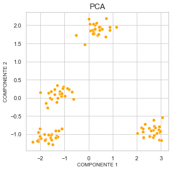

```python
plt.subplots(figsize=(5,5))
sns.scatterplot(x=xs, y=ys, color='orange')
plt.xlabel("COMPONENTE 1", fontsize = 10)
plt.ylabel("COMPONENTE 2", fontsize = 10)
plt.title('PCA', fontsize = 15)
sns.set(rc={"figure.figsize":(8, 4)})
plt.figure(num=None, figsize=(7, 7), dpi=80, facecolor='w', edgecolor='k')
```

El vector que define la primera componente principal sigue la dirección en la que las observaciones varían más. La proyección de cada observación sobre esa dirección equivale al valor de la primera componente para dicha observación. La segunda componente sigue la segunda dirección en la que los datos muestran mayor varianza y que no está correlacionada con la primera componente. En este caso, estamos trabajando sobre un dataset con muy pocas varaibles, por tanto el PCA no es claro del todo. Se puede decir que el Componente 1 explica la mayor varianza pero lo comprobaremos a continuación.

```python
main_vars1ej=sorted([(abs(el), i) for i, el in enumerate(pcacamp.components_[0])], reverse=True)
main_vars1ej[:3]
```

```
[(0.5296444656583245, 1), (0.5273915448444004, 0), (0.4965319618655622, 2)]
```

```python
[campaign_norm.columns[i] for n, i in main_vars1ej[:3]]
```

```
['prob_drink', 'prob_food', 'outdate']
```

Las variables que forman el componente 1 son la probabilidad de que la oferta sea bebida (prob_drink), comida (prob_food) y los días de validez de la oferta (outdate).

```python
main_vars1ej=sorted([(abs(el), i) for i, el in enumerate(pcacamp.components_[1])], reverse=True)
main_vars1ej[:3]
```

```
[(0.7974550289047789, 4), (0.5532146369240672, 3), (0.23229039351833572, 2)]
```

```python
[campaign_norm.columns[i] for n, i in main_vars1ej[:3]]
```

```
['discount', 'price', 'outdate']
```

Las variables que forman el componente 2 son el precio original del producto ofertado (price), el descuento sobre el precio (discount) y los días de validez de la oferta (outdate). Como podemos ver, la variable outdate aparece tanto en el componente 1 como el componente 2 y hemos intuido que esto se debe al pequeño tamaño de la base de datos que estamos analizando.

```python
main_vars1ej=sorted([(abs(el), i) for i, el in enumerate(pcacamp.components_[2])], reverse=True)
main_vars1ej[:3]
```

```
[(0.6644947103160163, 2), (0.48659095833917315, 0), (0.4318156992044374, 1)]
```

```python
[campaign_norm.columns[i] for n, i in main_vars1ej[:3]]
```

```
['outdate', 'prob_food', 'prob_drink']
```

```python
two_compc=sum(pcacamp.explained_variance_ratio_[:2])
three_compc=sum(pcacamp.explained_variance_ratio_[:3])
four_compc=sum(pcacamp.explained_variance_ratio_[:4])
```

```python
print("La  varianza explicada con los dos primeros componentes es", two_compc)
print("La  varianza explicada con los tres primeros componentes es", three_compc)
print("La  varianza explicada con los cuatro primeros componentes es", four_compc)
```

```
La  varianza explicada con los dos primeros componentes es 0.8851992682320791
La  varianza explicada con los tres primeros componentes es 0.9644284676591269
La  varianza explicada con los cuatro primeros componentes es 0.9940787411088661
```

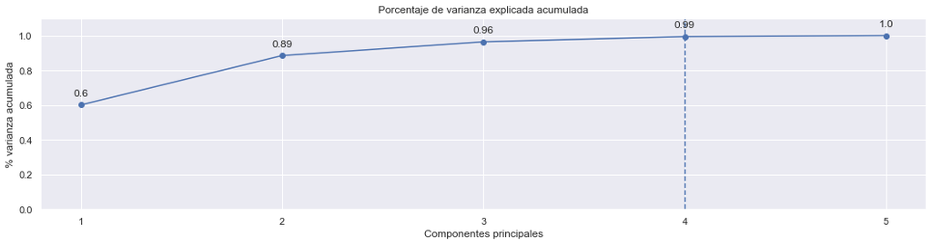

```python
prop_varianza_acum = pcacamp.explained_variance_ratio_.cumsum()
fig, ax = plt.subplots(nrows=1, ncols=1, figsize=(18, 4))
ax.plot(
    np.arange(pcacamp.n_components_) + 1,
    prop_varianza_acum,
    marker = 'o'
)

for x, y in zip(np.arange(pcacamp.n_components_) + 1, prop_varianza_acum):
    label = round(y, 2)
    ax.annotate(
        label,
        (x,y),
        textcoords="offset points",
        xytext=(0,10),
        ha='center'
    )

ax.axvline(x=4, linestyle = '--') #en el 4 componente se explica el 99% de la varianza
ax.set_ylim(0, 1.1)
ax.set_xticks(np.arange(pcacamp.n_components_) + 1)
ax.set_title('Porcentaje de varianza explicada acumulada')
ax.set_xlabel('Componentes principales')
ax.set_ylabel('% varianza acumulada')
```

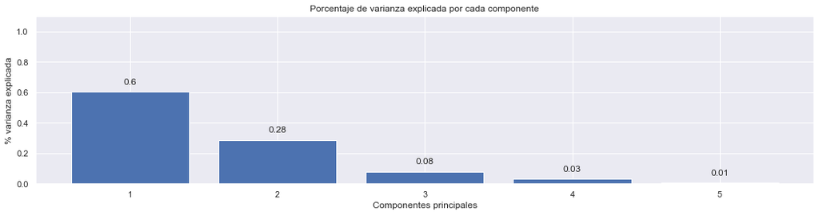

```python
fig, ax = plt.subplots(nrows=1, ncols=1, figsize=(18, 4))
ax.bar(
    x      = np.arange(pcacamp.n_components_) + 1,
    height = pcacamp.explained_variance_ratio_
)

for x, y in zip(np.arange(pcacamp.n_components_) + 1, pcacamp.explained_variance_ratio_):
    label = round(y, 2)
    ax.annotate(
        label,
        (x,y),
        textcoords="offset points",
        xytext=(0,10),
        ha='center'
    )

ax.set_xticks(np.arange(pcacamp.n_components_) + 1)
ax.set_ylim(0, 1.1)
ax.set_title('Porcentaje de varianza explicada por cada componente')
ax.set_xlabel('Componentes principales')
ax.set_ylabel('% varianza explicada')
```

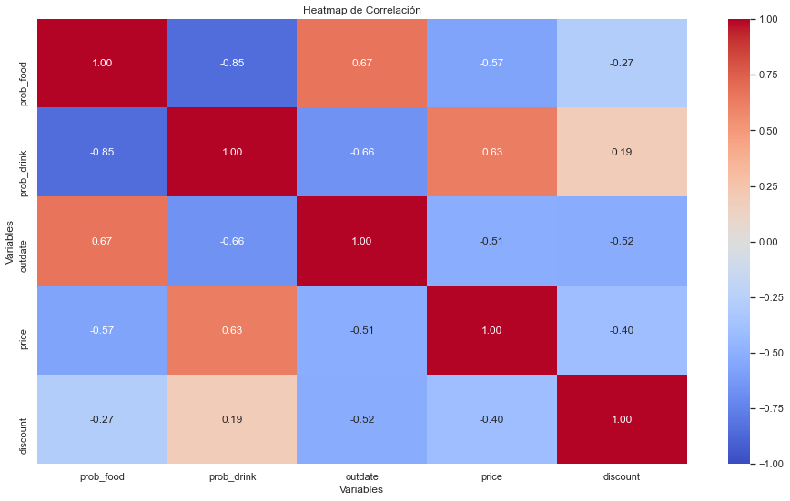

```python
corrcamp = campaign_norm.corr()

plt.figure(figsize=(16,9))
ax=sns.heatmap(corrcamp, cmap='coolwarm',
               annot=True,
              vmin=-1,
               vmax=1,
               center=0,fmt='.2f')
ax.set(title='Heatmap de Correlación',
      ylabel='Variables',
      xlabel='Variables')
plt.show()
```

#### 3.4 Haz un clustering haciendo uso de K-means, de la base de datos de campañas. Recuerda optimizar el valor adecuado de componentes.

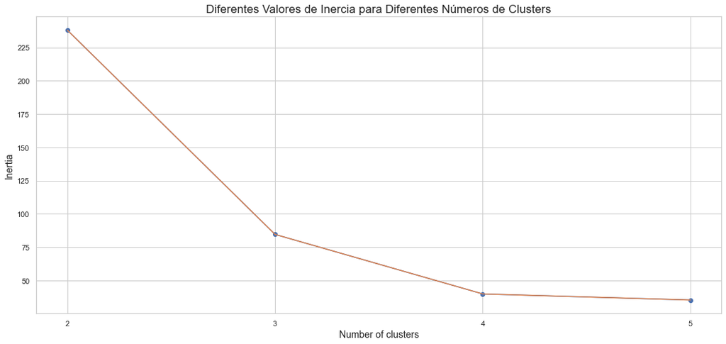

```python
plt.rcParams['figure.figsize'] = [8,8]
sns.set_style("whitegrid")
colors = plt.rcParams['axes.prop_cycle'].by_key()['color']

# Computar la inercia

inertias = []

for i in range(2, 6):
    km = KMeans(n_clusters=i, max_iter=1000, random_state=random_state)
    km.fit(campaign_norm)
    inertias.append(km.inertia_)

# Mostrar el plot de inercia vs. número de clusters

fig, ax = plt.subplots(figsize=(18, 8))

ax.plot(np.arange(2, 6, 1), inertias)
ax.set_xlabel('Number of clusters', fontsize=14)
ax.set_ylabel('Inertia', fontsize=14)
ax.set_xticks(np.arange(1, 6, 1))

plt.plot(range(2,6),inertias)
plt.scatter(range(2,6),inertias)

plt.title("Diferentes Valores de Inercia para Diferentes Números de Clusters", size=17)

plt.show()
```

Analizamos el gráfico de inercia y por la regla del codo obtenemos que el número óptimo de clusters es 4. Por ello, utilizaremos este número a la hora de realizar los clusters con KMeans como se muestra a continuación:

```python
kmeansclustc=KMeans(n_clusters=4)
```

```python
labels4c=kmeansclustc.fit_predict(campaign_norm)
```

```python
campaign_norm['Cluster']=labels4c
```

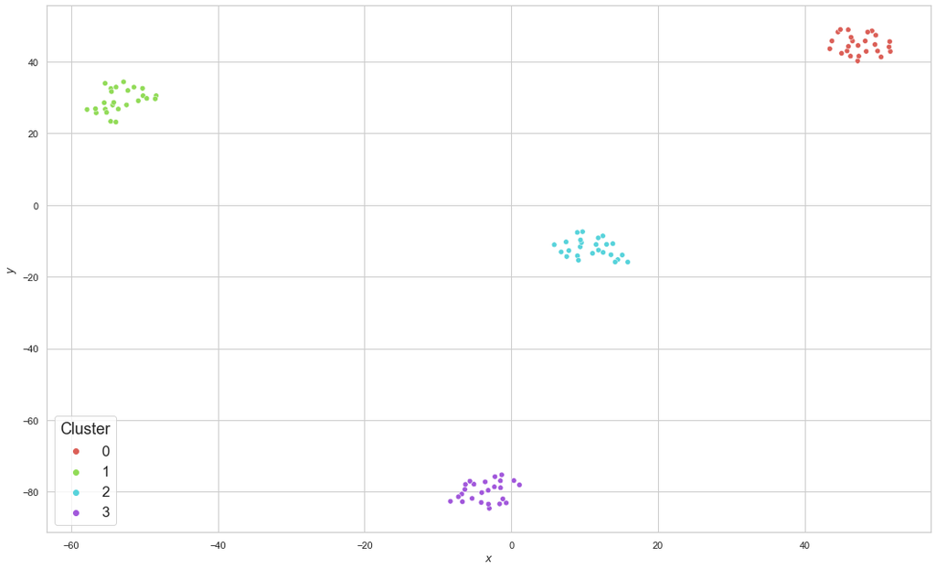

```python
tsne = TSNE(n_components=2, perplexity=10, random_state=random_state)
data_tsne = tsne.fit_transform(campaign_norm)

df_tsne = pd.DataFrame(data_tsne, columns=['x', 'y'], index=campaign_norm.index)
dff = pd.concat([campaign_norm, df_tsne], axis=1)

# Diagrama

fig, ax = plt.subplots(figsize=(18, 11))
with sns.plotting_context("notebook", font_scale=1.5):
    sns.scatterplot(x='x',
                    y='y',
                    hue='Cluster',
                    palette=sns.color_palette("hls", 4),
                    data=dff,
                    ax=ax)

ax.set_xlabel(r'$x$')
ax.set_ylabel(r'$y$')

plt.show()
```

Hemos utilizado un valor de perplexity relativamente bajo porque al trabajar con un número tan reducido de variables, este valor del parámetro ha sido óptimo para visualizar los clusters. En este clustering observamos claramente las cuatro agrupaciones de campañas. Esta segmentación se puede haber producido por las distintas características de las campañas, como los precios de los productos o los descuentos de los mismos, por ejemplo. Este clustering que acabamos de obtener nos va a servir más adelante para relacionar cada tipo de campaña con el grupo de clientes oportuno

#### 4.- Haciendo uso del dataset de entrenamiento de campaigns_to_customers_launched.csv, calcula el valor esperado de éxito para cluster de campañas mostrado a cada cluster de clientes. Este valor esperado, podría representar, de forma aproximada, por cada combinación de clusters campaña-cliente, la probabilidad de éxito al ofrecer una campaña al azar de un cluster de campañas a un cliente al azar de un cluster de clientes.

Para obtener el valor de la probabilidad que un cliente acepte la campaña creada para el grupo de clientes al que pertenece, calcularemos la media del resultado de aceptar la oferta por dicho cluster. Para cada cluster de campaña y cliente calcularemos media y valor esperaado de la combinacion de clusters. Utilizaremos el dataset de entrenamiento de campaigns_to_customers_launched, que hemos creado al principio del estudio, data_train. Primero realizamos unos filtrados de los datos para obtener una idea general de cuántos clientes rechazan la campaña, es decir, la columna de result tiene valor igual a cero y cuantos la aceptan, es decir, result igual a uno.

```python
result0=data['result']==0
filtered_df = data[result0]
filtered_df.head(5) # aquí mostramos los clientes que han rechazado la campaña
```

|  | customer | campaign | result |
| --- | --- | --- | --- |
| 1 | 1168 | 85 | 0 |
| 2 | 2142 | 36 | 0 |
| 3 | 1536 | 12 | 0 |
| 4 | 1072 | 74 | 0 |
| 7 | 1918 | 98 | 0 |

```python
result1=data['result']==1 # campañas aceptadas por el cliente
filtered_df = data[result1]
filtered_df.head(5)
```

|  | customer | campaign | result |
| --- | --- | --- | --- |
| 0 | 1650 | 34 | 1 |
| 5 | 1423 | 19 | 1 |
| 6 | 1300 | 68 | 1 |
| 11 | 1605 | 85 | 1 |
| 13 | 1693 | 23 | 1 |

```python
campana = filtered_df.groupby('campaign')
campana.agg('count')
```

| campaign | customer | result |
| --- | --- | --- |
| 0 | 40 | 40 |
| 1 | 30 | 30 |
| 2 | 41 | 41 |
| 3 | 29 | 29 |
| 4 | 27 | 27 |
| ... | ... | ... |
| 95 | 45 | 45 |
| 96 | 34 | 34 |
| 97 | 54 | 54 |
| 98 | 40 | 40 |
| 99 | 50 | 50 |

100 rows × 2 columns

Comprobamos que hay un total de 100 campañas y a continuación creamos una nueva variable llamada cluster_customer donde se asigna a cada cliente uno de los 20 clusters de clientes.

```python
kmeansclust6=KMeans(20)
```

```python
labls6=kmeansclust6.fit_predict(custnorm)
```

```python
customerdf['cluster_customer']=labls6
```

```python
customerdf.head()
```

|  | customer_id | Year_Birth | Education | Marital_Status | Income | Kidhome | Teenhome | Dt_Customer | Recency | MntWines | ... | NumDealsPurchases | NumWebPurchases | NumCatalogPurchases | NumStorePurchases | NumWebVisitsMonth | Complain | Z_CostContact | Z_Revenue | Response | cluster_customer |
| --- | --- | --- | --- | --- | --- | --- | --- | --- | --- | --- | --- | --- | --- | --- | --- | --- | --- | --- | --- | --- | --- |
| 0 | 0 | 1957 | Graduation | Single | 58138.0 | 0 | 0 | 2012-09-04 | 58 | 635 | ... | 3 | 8 | 10 | 4 | 7 | 0 | 3 | 11 | 1 | 3 |
| 1 | 1 | 1954 | Graduation | Single | 46344.0 | 1 | 1 | 2014-03-08 | 38 | 11 | ... | 2 | 1 | 1 | 2 | 5 | 0 | 3 | 11 | 0 | 16 |
| 2 | 2 | 1965 | Graduation | Together | 71613.0 | 0 | 0 | 2013-08-21 | 26 | 426 | ... | 1 | 8 | 2 | 10 | 4 | 0 | 3 | 11 | 0 | 14 |
| 3 | 3 | 1984 | Graduation | Together | 26646.0 | 1 | 0 | 2014-02-10 | 26 | 11 | ... | 2 | 2 | 0 | 4 | 6 | 0 | 3 | 11 | 0 | 0 |
| 4 | 4 | 1981 | PhD | Married | 58293.0 | 1 | 0 | 2014-01-19 | 94 | 173 | ... | 5 | 5 | 3 | 6 | 5 | 0 | 3 | 11 | 0 | 10 |

5 rows × 25 columns

```python
custnorm_id=customerdf[['customer_id','cluster_customer']]
custnorm_id=custnorm_id.rename(columns={'customer_id':'customer'})
custnorm_id.head()
```

|  | customer | cluster_customer |
| --- | --- | --- |
| 0 | 0 | 3 |
| 1 | 1 | 16 |
| 2 | 2 | 14 |
| 3 | 3 | 0 |
| 4 | 4 | 10 |

```python
#utilizamos el dataset de entrenamiento de campaigns_to_customers_launched.csv
customercluster=data_train.merge(custnorm_id, on='customer', how='inner')
```

```python
customercluster.head()
```

|  | customer | campaign | result | cluster_customer |
| --- | --- | --- | --- | --- |
| 0 | 1029 | 78 | 1 | 4 |
| 1 | 1029 | 63 | 1 | 4 |
| 2 | 1029 | 81 | 0 | 4 |
| 3 | 1029 | 89 | 0 | 4 |
| 4 | 1351 | 98 | 0 | 3 |

```python
kmeansclustc=KMeans(n_clusters=4)
labels4c=kmeansclustc.fit_predict(campaign_norm)
```

```python
campaigndf['Cluster_campaign']=labels4c
campaigndf.head()
```

|  | campaign_id | prob_food | prob_drink | outdate | price | discount | name | Cluster_campaign |
| --- | --- | --- | --- | --- | --- | --- | --- | --- |
| 0 | 0 | 0.54 | 0.22 | 4.0 | 40.39 | 19.35 | campaign_1 | 0 |
| 1 | 1 | 0.47 | 0.48 | 4.0 | 39.30 | 20.94 | campaign_2 | 0 |
| 2 | 2 | 0.56 | 0.28 | 10.0 | 30.19 | 10.88 | campaign_3 | 3 |
| 3 | 3 | 0.50 | 0.37 | 11.0 | 31.30 | 12.70 | campaign_4 | 3 |
| 4 | 4 | 0.55 | 0.44 | 2.0 | 39.68 | 20.69 | campaign_5 | 0 |

```python
campnorm_id=campaigndf[['campaign_id','Cluster_campaign']]
campnorm_id=campnorm_id.rename(columns={'campaign_id':'campaign'})
campnorm_id.head()
```

|  | campaign | Cluster_campaign |
| --- | --- | --- |
| 0 | 0 | 0 |
| 1 | 1 | 0 |
| 2 | 2 | 3 |
| 3 | 3 | 3 |
| 4 | 4 | 0 |

Ahora realizamos un merge del dataset customercluster con campnorm_id, con la campaña correspodiente que tengan en común

```python
cluster=customercluster.merge(campnorm_id, on='campaign', how='inner')
cluster
```

|  | customer | campaign | result | cluster_customer | Cluster_campaign |
| --- | --- | --- | --- | --- | --- |
| 0 | 1029 | 78 | 1 | 4 | 1 |
| 1 | 872 | 78 | 0 | 0 | 1 |
| 2 | 1387 | 78 | 0 | 7 | 1 |
| 3 | 1206 | 78 | 1 | 19 | 1 |
| 4 | 2186 | 78 | 0 | 18 | 1 |
| ... | ... | ... | ... | ... | ... |
| 8059 | 400 | 51 | 0 | 7 | 0 |
| 8060 | 1878 | 51 | 1 | 4 | 0 |
| 8061 | 1878 | 51 | 1 | 4 | 0 |
| 8062 | 96 | 51 | 1 | 17 | 0 |
| 8063 | 355 | 51 | 0 | 15 | 0 |

8064 rows × 5 columns

```python
cluster.groupby(['cluster_customer','Cluster_campaign']).mean()
```

| cluster_customer | Cluster_campaign | customer | campaign | result |
| --- | --- | --- | --- | --- |
| 0 | 0 | 1333.095238 | 43.823129 | 0.136054 |
|  | 1 | 1205.832000 | 42.240000 | 0.184000 |
|  | 2 | 1322.529801 | 65.139073 | 0.350993 |
|  | 3 | 1205.115108 | 48.719424 | 0.410072 |
| 1 | 0 | 991.418919 | 37.121622 | 0.027027 |
| ... | ... | ... | ... | ... |
| 18 | 3 | 1188.837209 | 48.418605 | 0.127907 |
| 19 | 0 | 1020.716049 | 41.345679 | 0.308642 |
|  | 1 | 951.193548 | 45.881720 | 0.311828 |
|  | 2 | 1040.373832 | 60.429907 | 0.271028 |
|  | 3 | 1036.113402 | 48.463918 | 0.319588 |

78 rows × 3 columns

Queremos calcular el valor esperado de éxito para cada cluster de campañas mostrado a cada cluster de clientes, es decir, el resultado que hemos obtenido es la media. La tabla que hemos obtenido es una fusión entre los clusters de clientes y los clusters de campañas. Agrupamos por cluster del cliente y cluster de campañas para obtener la tabla que necesitamos para el análisis de este apartado. Obtenemos así un dataset con los distintos clusters de clientes, y dentro de cada cluster de cliente encontramos las distintas campañas y la probabilidad de éxito de dicha campaña en dicho cluster de cliente. Comprobamos que tenemos 20 clusters de clientes y 4 clusters de campañas, como hemos indicado.

Por ejemplo, podemos comprobar que para el cluster de clientes número cero, la campaña óptima es la campaña 3 con una probabilidad de éxito de 0.41 (estos valores cambian cada vez que ejecutamos el código), que es un valor muy decente. Para el grupo de clientes número uno la campaña óptima es la dos con una probabilidad de éxito de 0.70, es decir, hay mucha probabilidad de que esa campaña sea aceptada por los clientes. El grupo 19 de clientes debería ser asignado la campaña 3 con una probabilidad de éxito de 0.319.

#### 5.- Evalua como de precisos son los modelos que hemos creado, contrastándolos contra el set de test. Para ello, simplemente tienes que calcular el error cuadrático medio, restando y elevando al cuadrado, el resultado de cada campaña que aparece en test menos la probabilidad de esa campaña teniendo en cuenta el cluster al que pertenece el cliente y el cluster al que pertenece la campaña.

Tendremos que coger el conjunto de datos de test (data_test) que hemos definido al principio del estudio con la función de sklearn train_test_split.

Merge combinará los objetos de nuestra base de datos con nombre con una unión al estilo de la misma. La unión se realizará sobre las columnas. En nuestro caso haremos una unión 'inner' que utiliza la intersección de las claves de ambos marcos conservando el orden de las claves de la izquierda.

Fusionaremos custnorm_id y data_test con la columna 'customer', que se encuentra en ambas tablas de datos:

```python
customercluster_test=data_test.merge(custnorm_id, on='customer', how='inner')
customercluster_test
```

|  | customer | campaign | result | cluster_customer |
| --- | --- | --- | --- | --- |
| 0 | 1942 | 82 | 0 | 16 |
| 1 | 1942 | 96 | 0 | 16 |
| 2 | 1584 | 43 | 1 | 5 |
| 3 | 1584 | 88 | 0 | 5 |
| 4 | 1584 | 11 | 0 | 5 |
| ... | ... | ... | ... | ... |
| 2683 | 2122 | 0 | 0 | 2 |
| 2684 | 706 | 13 | 0 | 6 |
| 2685 | 44 | 57 | 0 | 8 |
| 2686 | 362 | 71 | 0 | 2 |
| 2687 | 867 | 0 | 0 | 8 |

2688 rows × 4 columns

```python
cluster_test=customercluster_test.merge(campnorm_id, on='campaign', how='inner')
cluster_test
```

|  | customer | campaign | result | cluster_customer | Cluster_campaign |
| --- | --- | --- | --- | --- | --- |
| 0 | 1942 | 82 | 0 | 16 | 3 |
| 1 | 1881 | 82 | 0 | 10 | 3 |
| 2 | 1075 | 82 | 0 | 14 | 3 |
| 3 | 1934 | 82 | 0 | 5 | 3 |
| 4 | 1991 | 82 | 0 | 8 | 3 |
| ... | ... | ... | ... | ... | ... |
| 2683 | 566 | 18 | 0 | 4 | 1 |
| 2684 | 1299 | 18 | 0 | 16 | 1 |
| 2685 | 1270 | 18 | 0 | 4 | 1 |
| 2686 | 250 | 18 | 0 | 8 | 1 |
| 2687 | 849 | 18 | 0 | 2 | 1 |

2688 rows × 5 columns

Creamos un nuevo dataset llamado sol donde agrupamos el dataset de cluster_test por las columnas cluster_customer y Cluster_campaign y ejecutamos la media

```python
sol=cluster_test.groupby(['cluster_customer','Cluster_campaign']).mean()
```

Después, fusionamos esta nueva base de datos sol con cluster_test, en cluster_customer y Cluster_campaign que son columnas que se encuentran en ambas tablas de datos:

```python
cluster_test=cluster_test.merge(sol, on=['cluster_customer','Cluster_campaign'], how='inner')
cluster_test
```

|  | customer_x | campaign_x | result_x | cluster_customer | Cluster_campaign | customer_y | campaign_y | result_y |
| --- | --- | --- | --- | --- | --- | --- | --- | --- |
| 0 | 1942 | 82 | 0 | 16 | 3 | 1206.860465 | 53.046512 | 0.116279 |
| 1 | 1086 | 82 | 0 | 16 | 3 | 1206.860465 | 53.046512 | 0.116279 |
| 2 | 1193 | 82 | 1 | 16 | 3 | 1206.860465 | 53.046512 | 0.116279 |
| 3 | 1942 | 96 | 0 | 16 | 3 | 1206.860465 | 53.046512 | 0.116279 |
| 4 | 643 | 96 | 0 | 16 | 3 | 1206.860465 | 53.046512 | 0.116279 |
| ... | ... | ... | ... | ... | ... | ... | ... | ... |
| 2683 | 1180 | 73 | 0 | 15 | 2 | 840.800000 | 72.000000 | 0.000000 |
| 2684 | 1201 | 73 | 0 | 15 | 2 | 840.800000 | 72.000000 | 0.000000 |
| 2685 | 153 | 73 | 0 | 9 | 2 | 153.000000 | 73.000000 | 0.000000 |
| 2686 | 2202 | 54 | 1 | 12 | 3 | 2189.500000 | 58.500000 | 1.000000 |
| 2687 | 2177 | 63 | 1 | 12 | 3 | 2189.500000 | 58.500000 | 1.000000 |

2688 rows × 8 columns

Calcularemos el error cuadrático medio. Para ello, computamos el resultado de calcular cada campaña que aparece en test menos la probabilidad de esa campaña y después lo elevaremos al cuadrado.

Así recibiremos la información del cluster al que pertenece el cliente y el cluster al que pertenece la campaña.

```python
cluster_test['error']=cluster_test['result_x']-cluster_test['result_y']
cluster_test['error2']=cluster_test.error**2
cluster_test
```

|  | customer_x | campaign_x | result_x | cluster_customer | Cluster_campaign | customer_y | campaign_y | result_y | error | error2 |
| --- | --- | --- | --- | --- | --- | --- | --- | --- | --- | --- |
| 0 | 1942 | 82 | 0 | 16 | 3 | 1206.860465 | 53.046512 | 0.116279 | -0.116279 | 0.013521 |
| 1 | 1086 | 82 | 0 | 16 | 3 | 1206.860465 | 53.046512 | 0.116279 | -0.116279 | 0.013521 |
| 2 | 1193 | 82 | 1 | 16 | 3 | 1206.860465 | 53.046512 | 0.116279 | 0.883721 | 0.780963 |
| 3 | 1942 | 96 | 0 | 16 | 3 | 1206.860465 | 53.046512 | 0.116279 | -0.116279 | 0.013521 |
| 4 | 643 | 96 | 0 | 16 | 3 | 1206.860465 | 53.046512 | 0.116279 | -0.116279 | 0.013521 |
| ... | ... | ... | ... | ... | ... | ... | ... | ... | ... | ... |
| 2683 | 1180 | 73 | 0 | 15 | 2 | 840.800000 | 72.000000 | 0.000000 | 0.000000 | 0.000000 |
| 2684 | 1201 | 73 | 0 | 15 | 2 | 840.800000 | 72.000000 | 0.000000 | 0.000000 | 0.000000 |
| 2685 | 153 | 73 | 0 | 9 | 2 | 153.000000 | 73.000000 | 0.000000 | 0.000000 | 0.000000 |
| 2686 | 2202 | 54 | 1 | 12 | 3 | 2189.500000 | 58.500000 | 1.000000 | 0.000000 | 0.000000 |
| 2687 | 2177 | 63 | 1 | 12 | 3 | 2189.500000 | 58.500000 | 1.000000 | 0.000000 | 0.000000 |

2688 rows × 10 columns

El resultado que buscamos es el error cuadrático medio, es decir, la media de los datos de la variable que hemos creado, error 2:

```python
ECM = cluster_test['error2'].mean()
```

```python
print('El error cuadrático medio es igual a',ECM)
```

```
El error cuadrático medio es igual a 0.1568237508674348
```

#### 6.- Genera datos simulados:

#### 6.1 - Genera un cliente simulado. De que cluster de campañas le ofrecerías al azar una campaña con el objetivo de maximizar el éxito?

```python
cluster_test.sample(random_state=random_state)
```

|  | customer_x | campaign_x | result_x | cluster_customer | Cluster_campaign | customer_y | campaign_y | result_y | error | error2 |
| --- | --- | --- | --- | --- | --- | --- | --- | --- | --- | --- |
| 2282 | 1169 | 84 | 0 | 3 | 0 | 1100.965517 | 51.0 | 0.310345 | -0.310345 | 0.096314 |

#### 6.2 - Genera una campaña nueva simulada. A que cluster de clientes le ofrecerías la campaña con el objetivo de maximizar el éxito?.

```python
cluster_test.sample(random_state=random_state)
```

|  | customer_x | campaign_x | result_x | cluster_customer | Cluster_campaign | customer_y | campaign_y | result_y | error | error2 |
| --- | --- | --- | --- | --- | --- | --- | --- | --- | --- | --- |
| 2282 | 1169 | 84 | 0 | 3 | 0 | 1100.965517 | 51.0 | 0.310345 | -0.310345 | 0.096314 |

#### 7.- BONUS. PUNTO EXTRA: Realiza una optimización de tus modelos. Haciendo uso de los conocimientos de diferentes técnicas de clustering que conoces, y sus diferentes parámetros. Prueba diferentes combinaciones (todas las que quieras) para clusterizar tanto las campañas y los clientes y evalúalas contra el dataset de validación. Quédate con aquella que tenga el error cuadrático más pequeno. Una vez elegida la mejor combinación, evalúala contra el dataset de test. TIPS: puedes incluso combinar el hacer un PCA primero antes de aplicar clustering.

# KMEANS

```python
customercluster_val=data_validation.merge(custnorm_id, on='customer', how='inner')
customercluster_val
```

|  | customer | campaign | result | cluster_customer |
| --- | --- | --- | --- | --- |
| 0 | 868 | 91 | 0 | 4 |
| 1 | 868 | 2 | 0 | 4 |
| 2 | 432 | 96 | 1 | 4 |
| 3 | 1041 | 32 | 0 | 15 |
| 4 | 1041 | 17 | 0 | 15 |
| ... | ... | ... | ... | ... |
| 2683 | 1780 | 60 | 0 | 11 |
| 2684 | 246 | 53 | 0 | 4 |
| 2685 | 847 | 86 | 1 | 18 |
| 2686 | 1362 | 78 | 0 | 1 |
| 2687 | 146 | 94 | 0 | 2 |

2688 rows × 4 columns

```python
cluster_val=customercluster_val.merge(campnorm_id, on='campaign', how='inner')
cluster_val
```

|  | customer | campaign | result | cluster_customer | Cluster_campaign |
| --- | --- | --- | --- | --- | --- |
| 0 | 868 | 91 | 0 | 4 | 0 |
| 1 | 687 | 91 | 0 | 19 | 0 |
| 2 | 364 | 91 | 0 | 4 | 0 |
| 3 | 1344 | 91 | 0 | 11 | 0 |
| 4 | 2124 | 91 | 0 | 0 | 0 |
| ... | ... | ... | ... | ... | ... |
| 2683 | 367 | 82 | 0 | 6 | 3 |
| 2684 | 277 | 82 | 0 | 14 | 3 |
| 2685 | 3 | 82 | 0 | 0 | 3 |
| 2686 | 546 | 82 | 0 | 17 | 3 |
| 2687 | 431 | 82 | 0 | 4 | 3 |

2688 rows × 5 columns

```python
sol_val=cluster_val.groupby(['cluster_customer','Cluster_campaign']).mean()
```

```python
cluster_val=cluster_val.merge(sol_val, on=['cluster_customer','Cluster_campaign'], how='inner')
cluster_val
```

|  | customer_x | campaign_x | result_x | cluster_customer | Cluster_campaign | customer_y | campaign_y | result_y |
| --- | --- | --- | --- | --- | --- | --- | --- | --- |
| 0 | 868 | 91 | 0 | 4 | 0 | 972.149425 | 42.045977 | 0.37931 |
| 1 | 364 | 91 | 0 | 4 | 0 | 972.149425 | 42.045977 | 0.37931 |
| 2 | 1147 | 91 | 1 | 4 | 0 | 972.149425 | 42.045977 | 0.37931 |
| 3 | 154 | 91 | 1 | 4 | 0 | 972.149425 | 42.045977 | 0.37931 |
| 4 | 1951 | 40 | 1 | 4 | 0 | 972.149425 | 42.045977 | 0.37931 |
| ... | ... | ... | ... | ... | ... | ... | ... | ... |
| 2683 | 153 | 18 | 0 | 9 | 1 | 153.000000 | 18.000000 | 0.00000 |
| 2684 | 2093 | 11 | 0 | 13 | 3 | 2093.000000 | 11.000000 | 0.00000 |
| 2685 | 138 | 93 | 0 | 9 | 3 | 138.000000 | 81.000000 | 0.00000 |
| 2686 | 138 | 69 | 0 | 9 | 3 | 138.000000 | 81.000000 | 0.00000 |
| 2687 | 138 | 39 | 0 | 9 | 0 | 138.000000 | 39.000000 | 0.00000 |

2688 rows × 8 columns

```python
cluster_val['error']=cluster_val['result_x']-cluster_val['result_y']
cluster_val['error2']=cluster_val.error**2
cluster_val.head()
```

|  | customer_x | campaign_x | result_x | cluster_customer | Cluster_campaign | customer_y | campaign_y | result_y | error | error2 |
| --- | --- | --- | --- | --- | --- | --- | --- | --- | --- | --- |
| 0 | 868 | 91 | 0 | 4 | 0 | 972.149425 | 42.045977 | 0.37931 | -0.37931 | 0.143876 |
| 1 | 364 | 91 | 0 | 4 | 0 | 972.149425 | 42.045977 | 0.37931 | -0.37931 | 0.143876 |
| 2 | 1147 | 91 | 1 | 4 | 0 | 972.149425 | 42.045977 | 0.37931 | 0.62069 | 0.385256 |
| 3 | 154 | 91 | 1 | 4 | 0 | 972.149425 | 42.045977 | 0.37931 | 0.62069 | 0.385256 |
| 4 | 1951 | 40 | 1 | 4 | 0 | 972.149425 | 42.045977 | 0.37931 | 0.62069 | 0.385256 |

```python
cluster_val['error2'].mean()
```

```
0.15568300683341837
```